# Consuming Government Data

## with Python and d3

### by Pratap Vardhan ([@PratapVardhan](https://twitter.com/PratapVardhan))

At the end of this talk you will be familiar with

- Using Pandas to read and parse data
- Find patterns, anomalies in data
- Integrate d3.js based frameworks to your data pipeline

### Code at https://github.com/pratapvardhan/pycon-2015

# Government - Who's got the data?

Why do we even care about Government's data?

Among many reasons, Calvin has a strong point to make..

[figure not shown]

# Politics of Donations

[figure not shown]

# Let's read the data from database

We scraped the data from AAP donations website.

```python
import pandas as pd
import sqlite3
import matplotlib.pyplot as plt
%matplotlib inline
```

```python
con = sqlite3.connect("data/aapdonation.db")
```

```python
df = pd.read_sql('SELECT * FROM aapdonate', con, parse_dates=['DATE'])
```

```python
df.head()
```

|  | NAME | COUNTRY | STATE | TID | AMT | DATE |
| --- | --- | --- | --- | --- | --- | --- |
| 0 | MEHNDI HASAN | INDIA | DELHI | MO115400942 | 10 | 2015-01-02 14:38:00 |
| 1 | AMITABH | INDIA | DELHI | MO115400941 | 100 | 2015-01-02 14:33:00 |
| 2 | RAJPAL | INDIA | DELHI | MO115400940 | 500 | 2015-01-02 14:33:00 |
| 3 | SHARAD CHAUHAN | INDIA | TELANGANA | NE400939 | 1001 | 2015-01-02 14:33:00 |
| 4 | MITHLESH | INDIA | UTTAR PRADESH | NE400938 | 1 | 2015-01-02 14:32:00 |

# Getting some context around the data

#### Total Donation Amount

```python
'%.2f Crore' % (df['AMT'].sum() / 1e+7)
```

```
'81.33 Crore'
```

#### Total Number of Donations made

```python
"{:,}".format(df['AMT'].count())
```

```
'235,948'
```

#### Average Amount Donated

```python
"{0:.2f}".format(df['AMT'].mean())
```

```
'3446.82'
```

#### Single Highest Donation

```python
df.ix[df['AMT'].idxmax()]
```

```
NAME       BAJAJ ELECTORAL TRUST
COUNTRY                    INDIA
STATE                MAHARASHTRA
TID                  HO414362694
AMT                        3e+07
DATE         2014-07-05 17:55:00
Name: 16467, dtype: object
```

#### Super-PACs - More than 1 Lakh donation

```python
df[df['AMT'] > 1e+5]['AMT'].count(), '%.2f Crore' % (df[df['AMT'] > 1e+5]['AMT'].sum() / 1e+7)
```

```
(467, '26.69 Crore')
```

#### Using pd.describe()

```python
df['AMT'].describe()
```

```
count      235948.000000
mean         3446.823151
std         77225.614901
min             1.000000
25%           101.000000
50%           500.000000
75%          2000.000000
max      30000000.000000
Name: AMT, dtype: float64
```

# Resample timeseries

## Month-wise donations amounts

```python
df.set_index('DATE')['AMT'].resample('M', how='sum')
```

```
DATE
2012-11-30    5.335480e+05
2012-12-31    3.694378e+06
2013-01-31    8.014810e+05
2013-02-28    4.110186e+06
2013-03-31    4.870383e+06
2013-04-30    1.572727e+07
2013-05-31    7.174672e+06
2013-06-30    9.091356e+06
2013-07-31    1.532198e+07
2013-08-31    2.703926e+07
2013-09-30    4.217791e+07
2013-10-31    4.472144e+07
2013-11-30    2.511796e+07
2013-12-31    3.996024e+07
2014-01-31    4.469318e+07
2014-02-28    2.651878e+07
2014-03-31    9.424170e+07
2014-04-30    1.255169e+08
2014-05-31    4.017460e+07
2014-06-30    8.759813e+06
2014-07-31    5.081676e+07
2014-08-31    2.064085e+06
2014-09-30    1.057237e+06
2014-10-31    8.638310e+05
2014-11-30    1.107629e+07
2014-12-31    2.070332e+07
2015-01-31    9.170932e+07
2015-02-28    4.111570e+07
2015-03-31    6.057555e+06
2015-04-30    7.087900e+05
2015-05-31    1.884901e+06
2015-06-30    8.348890e+05
2015-07-31    4.131297e+06
Freq: M, Name: AMT, dtype: float64
```

## Month-wise - Number of donations made

```python
df.set_index('DATE')['AMT'].resample('M', how='count')
```

```
DATE
2012-11-30      957
2012-12-31      237
2013-01-31      552
2013-02-28     3370
2013-03-31     1987
2013-04-30     7413
2013-05-31     4816
2013-06-30     4981
2013-07-31     8286
2013-08-31     8500
2013-09-30     9516
2013-10-31    11386
2013-11-30     9620
2013-12-31    16132
2014-01-31    23514
2014-02-28    10820
2014-03-31    27486
2014-04-30    25378
2014-05-31     5326
2014-06-30      709
2014-07-31      489
2014-08-31     1288
2014-09-30      655
2014-10-31      469
2014-11-30     6115
2014-12-31     7037
2015-01-31    21517
2015-02-28    12327
2015-03-31      807
2015-04-30      363
2015-05-31      565
2015-06-30      463
2015-07-31     2867
Freq: M, Name: AMT, dtype: int64
```

## Combine both operations

```python
df.set_index('DATE').resample('M', how={'AMT': pd.np.sum, 'NAME': 'count'})
```

| DATE | AMT | NAME |
| --- | --- | --- |
| 2012-11-30 | 5.335480e+05 | 957 |
| 2012-12-31 | 3.694378e+06 | 237 |
| 2013-01-31 | 8.014810e+05 | 552 |
| 2013-02-28 | 4.110186e+06 | 3370 |
| 2013-03-31 | 4.870383e+06 | 1987 |
| 2013-04-30 | 1.572727e+07 | 7413 |
| 2013-05-31 | 7.174672e+06 | 4816 |
| 2013-06-30 | 9.091356e+06 | 4981 |
| 2013-07-31 | 1.532198e+07 | 8286 |
| 2013-08-31 | 2.703926e+07 | 8500 |
| 2013-09-30 | 4.217791e+07 | 9516 |
| 2013-10-31 | 4.472144e+07 | 11386 |
| 2013-11-30 | 2.511796e+07 | 9620 |
| 2013-12-31 | 3.996024e+07 | 16132 |
| 2014-01-31 | 4.469318e+07 | 23514 |
| 2014-02-28 | 2.651878e+07 | 10820 |
| 2014-03-31 | 9.424170e+07 | 27486 |
| 2014-04-30 | 1.255169e+08 | 25378 |
| 2014-05-31 | 4.017460e+07 | 5326 |
| 2014-06-30 | 8.759813e+06 | 709 |
| 2014-07-31 | 5.081676e+07 | 489 |
| 2014-08-31 | 2.064085e+06 | 1288 |
| 2014-09-30 | 1.057237e+06 | 655 |
| 2014-10-31 | 8.638310e+05 | 469 |
| 2014-11-30 | 1.107629e+07 | 6115 |
| 2014-12-31 | 2.070332e+07 | 7037 |
| 2015-01-31 | 9.170932e+07 | 21517 |
| 2015-02-28 | 4.111570e+07 | 12327 |
| 2015-03-31 | 6.057555e+06 | 807 |
| 2015-04-30 | 7.087900e+05 | 363 |
| 2015-05-31 | 1.884901e+06 | 565 |
| 2015-06-30 | 8.348890e+05 | 463 |
| 2015-07-31 | 4.131297e+06 | 2867 |

# Curse of sampling resolution

How we might miss out of sampling data points

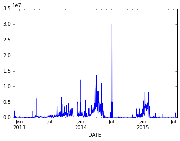

```python
df.set_index('DATE')['AMT'].resample('D', how='sum').plot();
```

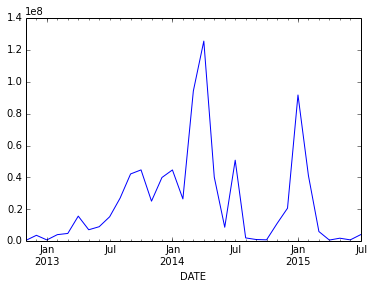

```python
df.set_index('DATE')['AMT'].resample('M', how='sum').plot();
```

# Javascript into IPython

Injecting html, js into browser

```python
from IPython.display import HTML

html = """<div id='time'></div>"""

javascript = """
<script type="text/Javascript">
(function () {
    function startTime() {
        document.getElementById('time').innerHTML = new Date();
        t = setTimeout(function () {
            startTime()}, 500);
    }
    startTime();
})();
</script>
"""
HTML(html + javascript)
```

## importing d3 and dimple

```python
%%javascript

require.config({
    shim: {
        d3: { exports: "d3" },
        dimple: {
            exports: "dimple",
            deps: ["d3"]
        }
    },
    paths: {
        d3: "/files/js/d3.v3.min",
        dimple: "/files/js/dimple.v1.1.5.amd"
    }
});


require(["d3", "dimple"], function(d3, dimple) {
  console.log(d3.version);
  console.log(dimple.version);
});
```

## Let's animate a rectangle

```python
html = """<div id='d3animate'></div>"""

js = """"<script type="text/Javascript">
var svg = d3.select("#d3animate")
  .append('svg')
  .attr("width", 600)
  .attr("height", 300);

var square = svg.append("rect")
  .attr("x", 30)
  .attr("y", 30)
  .attr("width", 30)
  .attr("height", 30)
  .attr("fill", "blue");

(function () {
  function d3animate() {
    square.transition()
      .attr("x", Math.random()*600)
      .attr("y", Math.random()*300)
      .duration(2000);
    setTimeout(function () { d3animate()}, 2000); }
    d3animate();
})();
</script>"""

HTML(html + js)
```

"

# Donations Tracker

location: https://gramener.com/aapdonations/

```python
from IPython.display import IFrame
IFrame('https://gramener.com/aapdonations/', width=1000, height=500)
```

[interactive chart not shown]

# Making of Treemaps

Get the states aggregates

```python
aap_states = (df.groupby('STATE')['AMT']
              .agg([pd.np.sum, 'count', pd.np.mean])
              .sort('count', ascending=False))
aap_states
```

| STATE | sum | count | mean |
| --- | --- | --- | --- |
| DELHI | 1.768298e+08 | 40565 | 4359.172267 |
| MAHARASHTRA | 1.481808e+08 | 29298 | 5057.710359 |
|  | 2.264414e+08 | 28431 | 7964.596584 |
| UTTAR PRADESH | 5.474770e+07 | 24235 | 2259.034496 |
| KARNATAKA | 4.768724e+07 | 22542 | 2115.484207 |
| HARYANA | 3.853400e+07 | 13491 | 2856.274776 |
| ANDHRA PRADESH | 1.625470e+07 | 9308 | 1746.315428 |
| TAMIL NADU | 1.826528e+07 | 7843 | 2328.864083 |
| PUNJAB | 1.052215e+07 | 6915 | 1521.641504 |
| RAJASTHAN | 9.274608e+06 | 6430 | 1442.396267 |
| MADHYA PRADESH | 6.584245e+06 | 6005 | 1096.460450 |
| BIHAR | 3.721163e+06 | 5713 | 651.350079 |
| KERALA | 6.993397e+06 | 5614 | 1245.706626 |
| ODISHA | 5.236809e+06 | 5140 | 1018.834436 |
| GUJARAT | 1.266896e+07 | 5083 | 2492.418454 |
| WEST BENGAL | 9.563113e+06 | 4878 | 1960.457770 |
| UTTARAKHAND | 3.470537e+06 | 2606 | 1331.748734 |
| JHARKHAND | 1.861813e+06 | 2395 | 777.374948 |
| CHHATTISGARH | 3.941208e+06 | 2319 | 1699.529107 |
| HIMACHAL PRADESH | 2.310535e+06 | 1516 | 1524.099604 |
| CHANDIGARH | 3.946690e+06 | 1442 | 2736.955617 |
| ASSAM | 1.035219e+06 | 1394 | 742.624821 |
| TELANGANA | 2.425725e+06 | 852 | 2847.095070 |
| GOA | 1.054709e+06 | 613 | 1720.569331 |
| JAMMU & KASHMIR | 4.044390e+05 | 396 | 1021.310606 |
| TRIPURA | 9.086500e+04 | 168 | 540.863095 |
| PUDUCHERRY | 5.676940e+05 | 168 | 3379.130952 |
| ANDAMAN & NICOBAR ISLANDS | 6.914800e+04 | 112 | 617.392857 |
| ARUNACHAL PRADESH | 1.388650e+05 | 89 | 1560.280899 |
| MANIPUR | 8.226100e+04 | 81 | 1015.567901 |
| MEGHALAYA | 7.135000e+04 | 77 | 926.623377 |
| DADRA & NAGAR HAVELI | 8.032900e+04 | 65 | 1235.830769 |
| SIKKIM | 8.590000e+04 | 48 | 1789.583333 |
| NAGALAND | 8.080100e+04 | 45 | 1795.577778 |
| DAMAN AND DIU | 2.459400e+04 | 38 | 647.210526 |
| MIZORAM | 1.606700e+04 | 17 | 945.117647 |
| LAKSHADWEEP | 6.830000e+03 | 16 | 426.875000 |

## Get the country aggregates

```python
aap_countries = (df[df['COUNTRY'] != 'INDIA']
                 .groupby('COUNTRY')['AMT']
                 .agg([pd.np.sum, 'count', pd.np.mean])
                 .sort('count', ascending=False))
aap_countries
```

| COUNTRY | sum | count | mean |
| --- | --- | --- | --- |
| UNITED STATES | 75757883.00 | 10562 | 7172.683488 |
| UNITED ARAB EMIRATES | 33310691.00 | 2916 | 11423.419410 |
| UNITED KINGDOM | 13841939.00 | 2387 | 5798.885212 |
| SINGAPORE | 16435337.80 | 1826 | 9000.732640 |
| CANADA | 20303045.95 | 1671 | 12150.236954 |
| AUSTRALIA | 10889004.00 | 1543 | 7057.034349 |
| QATAR | 3251971.00 | 778 | 4179.911311 |
| SAUDI ARABIA | 2172966.00 | 732 | 2968.532787 |
| KUWAIT | 1967152.00 | 556 | 3538.043165 |
| GERMANY | 2337111.00 | 443 | 5275.645598 |
| NEW ZEALAND | 3661629.00 | 427 | 8575.243560 |
| OMAN | 1306199.00 | 295 | 4427.793220 |
| JAPAN | 1204325.00 | 251 | 4798.107570 |
| BAHRAIN | 1089864.00 | 212 | 5140.867925 |
| SWITZERLAND | 1382066.00 | 204 | 6774.833333 |
| NETHERLANDS | 1190038.00 | 195 | 6102.758974 |
| MALAYSIA | 823572.00 | 169 | 4873.207101 |
| HONG KONG | 20594920.00 | 161 | 127918.757764 |
| FRANCE | 703261.00 | 147 | 4784.088435 |
| SWEDEN | 664546.00 | 147 | 4520.721088 |
| KOREA, REPUBLIC OF | 449921.00 | 107 | 4204.869159 |
| IRELAND | 610118.00 | 107 | 5702.037383 |
| THAILAND | 412631.34 | 100 | 4126.313400 |
| NORWAY | 600507.00 | 76 | 7901.407895 |
| NIGERIA | 328743.00 | 76 | 4325.565789 |
| BELGIUM | 383730.00 | 66 | 5814.090909 |
| INDONESIA | 1226269.00 | 60 | 20437.816667 |
| ITALY | 211216.00 | 52 | 4061.846154 |
| FINLAND | 186113.00 | 51 | 3649.274510 |
| DENMARK | 320675.00 | 44 | 7288.068182 |
| ... | ... | ... | ... |
| SVALBARD AND JAN MAYEN ISLANDS | 20001.00 | 1 | 20001.000000 |
| UZBEKISTAN | 10000.00 | 1 | 10000.000000 |
| TAJIKISTAN | 10000.00 | 1 | 10000.000000 |
| SYRIAN ARAB REPUBLIC | 400.00 | 1 | 400.000000 |
| KYRGYZSTAN | 10.00 | 1 | 10.000000 |
| SOMALIA | 200000.00 | 1 | 200000.000000 |
| GEORGIA | 1000.00 | 1 | 1000.000000 |
| BARBADOS | 5000.00 | 1 | 5000.000000 |
| BURUNDI | 1000.00 | 1 | 1000.000000 |
| COSTA RICA | 2014.00 | 1 | 2014.000000 |
| COTE D'IVOIRE | 20000.00 | 1 | 20000.000000 |
| EAST TIMOR | 555.00 | 1 | 555.000000 |
| ECUADOR | 5000.00 | 1 | 5000.000000 |
| EQUATORIAL GUINEA | 5000.00 | 1 | 5000.000000 |
| ESTONIA | 500.00 | 1 | 500.000000 |
| FALKLAND ISLANDS (MALVINAS) | 5000.00 | 1 | 5000.000000 |
| FRANCE, METROPOLITAN | 2500.00 | 1 | 2500.000000 |
| GRENADA | 5000.00 | 1 | 5000.000000 |
| SENEGAL | 5101.00 | 1 | 5101.000000 |
| GUAM | 8000.00 | 1 | 8000.000000 |
| HOLY SEE (VATICAN CITY STATE) | 10.00 | 1 | 10.000000 |
| LEBANON | 500.00 | 1 | 500.000000 |
| MACAU | 10000.00 | 1 | 10000.000000 |
| MACEDONIA | 1000.00 | 1 | 1000.000000 |
| MONACO | 201.00 | 1 | 201.000000 |
| MYANMAR (Burma)&#160; | 500.00 | 1 | 500.000000 |
| NEPAL | 51.00 | 1 | 51.000000 |
| NICARAGUA | 1000.00 | 1 | 1000.000000 |
| PUERTO RICO | 5000.00 | 1 | 5000.000000 |
|  | 2015.00 | 1 | 2015.000000 |

130 rows × 3 columns

## Working on meta-data

Creating custom binned buckets

```python
_BINS = [1, 100, 500, 1000, 5000, 10000, pd.np.inf]
pd.np.histogram(df['AMT'], bins=_BINS)[0]
```

```
array([30225, 55149, 45516, 71030, 17721, 16307])
```

```python
df['AMT-bucket'] = pd.cut(df['AMT'], _BINS, right=False)
df.head()
```

|  | NAME | COUNTRY | STATE | TID | AMT | DATE | AMT-bucket |
| --- | --- | --- | --- | --- | --- | --- | --- |
| 0 | MEHNDI HASAN | INDIA | DELHI | MO115400942 | 10 | 2015-01-02 14:38:00 | [1, 100) |
| 1 | AMITABH | INDIA | DELHI | MO115400941 | 100 | 2015-01-02 14:33:00 | [100, 500) |
| 2 | RAJPAL | INDIA | DELHI | MO115400940 | 500 | 2015-01-02 14:33:00 | [500, 1000) |
| 3 | SHARAD CHAUHAN | INDIA | TELANGANA | NE400939 | 1001 | 2015-01-02 14:33:00 | [1000, 5000) |
| 4 | MITHLESH | INDIA | UTTAR PRADESH | NE400938 | 1 | 2015-01-02 14:32:00 | [1, 100) |

# Denominations vs States Distributions

Understanding distributions of denominations across states

```python
(df.groupby(['STATE', 'AMT-bucket'])['TID'].count())
```

```
STATE                      AMT-bucket
ANDAMAN & NICOBAR ISLANDS  [1, 100)           45
                           [100, 500)         26
                           [1000, 5000)       16
                           [10000, inf)        1
                           [500, 1000)        20
                           [5000, 10000)       4
ANDHRA PRADESH             [1, 100)          976
                           [100, 500)       2417
                           [1000, 5000)     2953
                           [10000, inf)      406
                           [500, 1000)      2009
                           [5000, 10000)     547
ARUNACHAL PRADESH          [1, 100)           19
                           [100, 500)         22
```

[output cut: 48 more lines]

# Let's use pivots

Anytime, you do a groupby and stack it, you may want to use pivots

```python
pd.pivot_table(df, index='STATE', columns='AMT-bucket', values='TID', aggfunc='count')
```

| AMT-bucket STATE | [1, 100) | [100, 500) | [1000, 5000) | [10000, inf) | [500, 1000) | [5000, 10000) |
| --- | --- | --- | --- | --- | --- | --- |
| ANDAMAN & NICOBAR ISLANDS | 45 | 26 | 16 | 1 | 20 | 4 |
| ANDHRA PRADESH | 976 | 2417 | 2953 | 406 | 2009 | 547 |
| ARUNACHAL PRADESH | 19 | 22 | 28 | 2 | 12 | 6 |
| ASSAM | 327 | 484 | 281 | 17 | 248 | 37 |
| BIHAR | 1605 | 1925 | 922 | 65 | 1068 | 128 |
| CHANDIGARH | 159 | 347 | 483 | 69 | 290 | 94 |
| CHHATTISGARH | 428 | 658 | 600 | 86 | 455 | 92 |
| DADRA & NAGAR HAVELI | 5 | 12 | 12 | NaN | 28 | 8 |
| DAMAN AND DIU | 10 | 10 | 9 | NaN | 8 | 1 |
| DELHI | 6813 | 10560 | 10200 | 3298 | 7339 | 2355 |
| GOA | 31 | 141 | 218 | 29 | 137 | 57 |
| GUJARAT | 971 | 1415 | 1276 | 207 | 961 | 253 |
| HARYANA | 1408 | 3158 | 4260 | 842 | 2892 | 931 |
| HIMACHAL PRADESH | 189 | 428 | 433 | 48 | 368 | 50 |
| JAMMU & KASHMIR | 84 | 116 | 86 | 9 | 85 | 16 |
| JHARKHAND | 553 | 781 | 446 | 31 | 494 | 90 |
| KARNATAKA | 1700 | 4421 | 8418 | 1161 | 5124 | 1718 |
| KERALA | 565 | 1503 | 1891 | 136 | 1265 | 254 |
| LAKSHADWEEP | 4 | 2 | 1 | NaN | 9 | NaN |
| MADHYA PRADESH | 1337 | 1747 | 1397 | 121 | 1183 | 220 |
| MAHARASHTRA | 2502 | 6334 | 9974 | 2115 | 6127 | 2246 |
| MANIPUR | 15 | 26 | 22 | 2 | 15 | 1 |
| MEGHALAYA | 10 | 29 | 20 | 1 | 16 | 1 |
| MIZORAM | 1 | 3 | 7 | NaN | 5 | 1 |
| NAGALAND | 7 | 14 | 9 | 2 | 6 | 7 |
| Non-Resident Indian | 872 | 1504 | 11723 | 5777 | 2528 | 6027 |
| ODISHA | 925 | 1859 | 1098 | 60 | 1085 | 113 |
| PUDUCHERRY | 18 | 41 | 54 | 13 | 33 | 9 |
| PUNJAB | 817 | 2008 | 1888 | 237 | 1620 | 345 |
| RAJASTHAN | 1334 | 1938 | 1465 | 153 | 1303 | 237 |
| SIKKIM | 9 | 12 | 10 | 2 | 14 | 1 |
| TAMIL NADU | 645 | 1858 | 2740 | 272 | 1831 | 497 |
| TELANGANA | 84 | 171 | 291 | 69 | 168 | 69 |
| TRIPURA | 65 | 39 | 27 | 1 | 33 | 3 |
| UTTAR PRADESH | 4375 | 6902 | 5964 | 835 | 5148 | 1011 |
| UTTARAKHAND | 376 | 773 | 684 | 72 | 590 | 111 |
| WEST BENGAL | 941 | 1465 | 1124 | 168 | 999 | 181 |

# Focus on Top-States

Filter the data via top states list

```python
pd.pivot_table(df[df['STATE'].isin(aap_states.index[:10])],
               index='STATE',
               columns='AMT-bucket',
               values='TID',
               aggfunc='count')
```

| AMT-bucket STATE | [1, 100) | [100, 500) | [1000, 5000) | [10000, inf) | [500, 1000) | [5000, 10000) |
| --- | --- | --- | --- | --- | --- | --- |
| ANDHRA PRADESH | 976 | 2417 | 2953 | 406 | 2009 | 547 |
| DELHI | 6813 | 10560 | 10200 | 3298 | 7339 | 2355 |
| HARYANA | 1408 | 3158 | 4260 | 842 | 2892 | 931 |
| KARNATAKA | 1700 | 4421 | 8418 | 1161 | 5124 | 1718 |
| MAHARASHTRA | 2502 | 6334 | 9974 | 2115 | 6127 | 2246 |
| PUNJAB | 817 | 2008 | 1888 | 237 | 1620 | 345 |
| RAJASTHAN | 1334 | 1938 | 1465 | 153 | 1303 | 237 |
| TAMIL NADU | 645 | 1858 | 2740 | 272 | 1831 | 497 |
| UTTAR PRADESH | 4375 | 6902 | 5964 | 835 | 5148 | 1011 |

# Curious case of transaction IDs

Why would a same transaction ID be issued to mulitple donations/people?

```python
aap_tids = df['TID'].value_counts()
aap_tids_df = df[df['TID'].isin(aap_tids[aap_tids>1].index)].sort('TID')
aap_tids_df
```

|  | NAME | COUNTRY | STATE | TID | AMT | DATE | AMT-bucket |
| --- | --- | --- | --- | --- | --- | --- | --- |
| 15000 | ANIL P WILSON | INDIA | DELHI | 35075 | 11000 | 2014-08-23 18:45:00 | [10000, inf) |
| 14999 | ANIL P WILSON | INDIA | DELHI | 35075 | 11000 | 2014-08-23 18:45:00 | [10000, inf) |
| 196139 | HIMANSHU PANWAR | INDIA | KARNATAKA | 4831286 | 1000 | 2013-01-12 13:44:00 | [1000, 5000) |
| 196140 | HIMANSHU PANWAR | INDIA | KARNATAKA | 4831286 | 1000 | 2013-01-12 13:44:00 | [1000, 5000) |
| 176595 | ALKA TIWARI | INDIA | UTTAR PRADESH | 7530657 | 1000 | 2013-06-14 19:23:00 | [1000, 5000) |
| 176593 | ALKA TIWARI | INDIA | UTTAR PRADESH | 7530657 | 1000 | 2013-06-14 19:25:00 | [1000, 5000) |
| 145680 | PRATYUSH MISHRA | UNITED STATES | Non-Resident Indian | 8942398 | 1000 | 2013-10-04 21:22:00 | [1000, 5000) |
| 145679 | PRATYUSH MISHRA | UNITED STATES | Non-Resident Indian | 8942398 | 1000 | 2013-10-04 21:22:00 | [1000, 5000) |
| 175149 | TUSHAR SHAH | INDIA | MAHARASHTRA | CCA13FAAK887 | 1000 | 2013-06-21 18:44:00 | [1000, 5000) |
| 175262 | HARISH KUMAR SHARMA | INDIA | HARYANA | CCA13FAAK887 | 1000 | 2013-06-21 11:25:00 | [1000, 5000) |
| 175016 | YASHDEEP GODHAL | INDIA | KARNATAKA | CCA13FAAL285 | 8000 | 2013-06-22 19:54:00 | [5000, 10000) |
| 174859 | PAWAN KUMAR SINGH | INDIA | UTTAR PRADESH | CCA13FAAL285 | 1000 | 2013-06-23 20:02:00 | [1000, 5000) |
| 174617 | KAUSHIK CHATTERJEE | INDIA | WEST BENGAL | CCA13FAAL729 | 300 | 2013-06-24 13:16:00 | [100, 500) |
| 174057 | SURESH SHRIVASTAV | INDIA | DELHI | CCA13FAAL729 | 10 | 2013-06-27 13:20:00 | [1, 100) |
| 173548 | SAURABH CHATTERJEE | INDIA | UTTAR PRADESH | CCA13FAAL919 | 2000 | 2013-06-29 09:26:00 | [1000, 5000) |
| 174510 | DHIREN MEHTA | INDIA | MAHARASHTRA | CCA13FAAL919 | 5000 | 2013-06-24 21:25:00 | [5000, 10000) |
| 168003 | ARVIND DEWAN | INDIA | DELHI | CCA13GAAO150 | 1000 | 2013-07-14 19:05:00 | [1000, 5000) |
| 173161 | ANKUR JAIN | INDIA | MAHARASHTRA | CCA13GAAO150 | 2000 | 2013-07-01 13:09:00 | [1000, 5000) |
| 173076 | VARAPRASAD REDDY JEERU | INDIA | ANDHRA PRADESH | CCA13GAAO327 | 5000 | 2013-07-01 19:57:00 | [5000, 10000) |
| 167669 | SAMIR BAINS | INDIA | UTTAR PRADESH | CCA13GAAO327 | 501 | 2013-07-16 11:19:00 | [500, 1000) |
| 167546 | VINOD SINGH | INDIA | HARYANA | CCA13GAAO388 | 1000 | 2013-07-16 19:23:00 | [1000, 5000) |
| 173022 | DEEPAK JAIN | INDIA | HARYANA | CCA13GAAO388 | 2000 | 2013-07-01 23:34:00 | [1000, 5000) |
| 167137 | R RAMANATHAN | INDIA | HARYANA | CCA13GAAO612 | 10000 | 2013-07-18 18:10:00 | [10000, inf) |
| 172832 | DEEP SATI | INDIA | HARYANA | CCA13GAAO612 | 101 | 2013-07-02 14:28:00 | [100, 500) |
| 166916 | SAMPATH KUVE | INDIA | KARNATAKA | CCA13GAAO806 | 1000 | 2013-07-20 09:19:00 | [1000, 5000) |
| 172712 | HITESH KUMAR NIGAM | INDIA | DELHI | CCA13GAAO806 | 101 | 2013-07-02 23:48:00 | [100, 500) |
| 166596 | GAGAN AGARWAL | INDIA | UTTAR PRADESH | CCA13GAAO867 | 3000 | 2013-07-20 15:46:00 | [1000, 5000) |
| 172647 | S. SREENIVASA PRASAD | INDIA | ANDHRA PRADESH | CCA13GAAO867 | 100 | 2013-07-03 10:32:00 | [100, 500) |
| 172127 | TARUN GUPTA | INDIA | MADHYA PRADESH | CCA13GAAP870 | 10000 | 2013-07-05 10:52:00 | [10000, inf) |
| 165407 | SEKHAR SUKUMAR | INDIA | KARNATAKA | CCA13GAAP870 | 3000 | 2013-07-27 17:08:00 | [1000, 5000) |
| ... | ... | ... | ... | ... | ... | ... | ... |
| 212590 | SAKSHI SRIVASTAVA | INDIA | UTTAR PRADESH | NE403724 | 1000 | 2015-01-05 13:23:00 | [1000, 5000) |
| 212591 | SAKSHI SRIVASTAVA | INDIA | UTTAR PRADESH | NE403724 | 1000 | 2015-01-05 13:23:00 | [1000, 5000) |
| 208491 | PIYUSH JAIN | INDIA | HARYANA | NE409897 | 5100 | 2015-01-14 11:45:00 | [5000, 10000) |
| 208490 | PIYUSH JAIN | INDIA | HARYANA | NE409897 | 5100 | 2015-01-14 11:45:00 | [5000, 10000) |
| 207491 | KISHAN SRINIVAS | INDIA | KARNATAKA | NE411604 | 3000 | 2015-01-15 11:21:00 | [1000, 5000) |
| 207490 | KISHAN SRINIVAS | INDIA | KARNATAKA | NE411604 | 3000 | 2015-01-15 11:21:00 | [1000, 5000) |
| 205950 | ANKIT SINGLA | UNITED STATES | Non-Resident Indian | NE414134 | 6100 | 2015-01-16 18:59:00 | [5000, 10000) |
| 205951 | ANKIT SINGLA | UNITED STATES | Non-Resident Indian | NE414134 | 6100 | 2015-01-16 18:59:00 | [5000, 10000) |
| 204050 | MANEESH SINGH | INDIA | UTTAR PRADESH | NE427683 | 101 | 2015-01-19 12:09:00 | [100, 500) |
| 204051 | MANEESH SINGH | INDIA | UTTAR PRADESH | NE427683 | 101 | 2015-01-19 12:09:00 | [100, 500) |
| 203770 | SHAHBAZ KHAN | INDIA | UTTAR PRADESH | NE428200 | 150 | 2015-01-19 19:36:00 | [100, 500) |
| 203771 | SHAHBAZ KHAN | INDIA | UTTAR PRADESH | NE428200 | 150 | 2015-01-19 19:36:00 | [100, 500) |
| 200130 | SUDHIR JHANGIANI | INDIA | MAHARASHTRA | NE434549 | 500 | 2015-01-23 15:45:00 | [500, 1000) |
| 200131 | SUDHIR JHANGIANI | INDIA | MAHARASHTRA | NE434549 | 500 | 2015-01-23 15:45:00 | [500, 1000) |
| 198630 | RAJESH THAKUR | INDIA | HIMACHAL PRADESH | NE437234 | 1000 | 2015-01-25 14:45:00 | [1000, 5000) |
| 198631 | RAJESH THAKUR | INDIA | HIMACHAL PRADESH | NE437234 | 1000 | 2015-01-25 14:45:00 | [1000, 5000) |
| 197891 | PREETESH ANAND | INDIA | BIHAR | NE438464 | 100 | 2015-01-26 12:45:00 | [100, 500) |
| 197890 | PREETESH ANAND | INDIA | BIHAR | NE438464 | 100 | 2015-01-26 12:45:00 | [100, 500) |
| 215252 | ORAGADAM M SARAVANAN | INDIA | TAMIL NADU | NE443154 | 100 | 2015-01-30 02:50:00 | [100, 500) |
| 215251 | ORAGADAM M SARAVANAN | INDIA | TAMIL NADU | NE443154 | 100 | 2015-01-30 02:50:00 | [100, 500) |
| 221442 | DEEPIKA RAO | INDIA | MAHARASHTRA | NE473111 | 500 | 2015-02-03 14:06:00 | [500, 1000) |
| 221443 | DEEPIKA RAO | INDIA | MAHARASHTRA | NE473111 | 500 | 2015-02-03 14:06:00 | [500, 1000) |
| 42800 | BHAVIK GANDHI | UNITED STATES | Non-Resident Indian | NI297529 | 2014 | 2014-04-05 12:48:00 | [1000, 5000) |
| 42799 | BHAVIK GANDHI | UNITED STATES | Non-Resident Indian | NI297529 | 2014 | 2014-04-05 12:48:00 | [1000, 5000) |
| 34160 | AMAR CHAND BIYANI | INDIA | CHHATTISGARH | NI322675 | 5000 | 2014-04-13 20:25:00 | [5000, 10000) |
| 34159 | AMAR CHAND BIYANI | INDIA | CHHATTISGARH | NI322675 | 5000 | 2014-04-13 20:25:00 | [5000, 10000) |
| 27719 | MOHAMMED YASEEN | INDIA | ANDHRA PRADESH | NI352614 | 2000 | 2014-04-21 17:31:00 | [1000, 5000) |
| 27720 | MOHAMMED YASEEN | INDIA | ANDHRA PRADESH | NI352614 | 2000 | 2014-04-21 17:31:00 | [1000, 5000) |
| 215912 | MEHARDEEP SINGH CHAHAL | AUSTRALIA | Non-Resident Indian | NI442031 | 10000 | 2015-01-29 13:29:00 | [10000, inf) |
| 215911 | MEHARDEEP SINGH CHAHAL | AUSTRALIA | Non-Resident Indian | NI442031 | 10000 | 2015-01-29 13:29:00 | [10000, inf) |

110 rows × 7 columns

## Different people with same TIDs

The problems in 2013

```python
aap_tids_drp = aap_tids_df.drop_duplicates(['NAME', 'COUNTRY', 'STATE', 'TID'])
aap_tids_drp.loc[:, 'TID_counts'] = aap_tids_drp.groupby('TID')['TID'].transform('count')
aap_tids_drp[aap_tids_drp['TID_counts']>1]
```

|  | NAME | COUNTRY | STATE | TID | AMT | DATE | AMT-bucket | TID_counts |
| --- | --- | --- | --- | --- | --- | --- | --- | --- |
| 175149 | TUSHAR SHAH | INDIA | MAHARASHTRA | CCA13FAAK887 | 1000 | 2013-06-21 18:44:00 | [1000, 5000) | 2 |
| 175262 | HARISH KUMAR SHARMA | INDIA | HARYANA | CCA13FAAK887 | 1000 | 2013-06-21 11:25:00 | [1000, 5000) | 2 |
| 175016 | YASHDEEP GODHAL | INDIA | KARNATAKA | CCA13FAAL285 | 8000 | 2013-06-22 19:54:00 | [5000, 10000) | 2 |
| 174859 | PAWAN KUMAR SINGH | INDIA | UTTAR PRADESH | CCA13FAAL285 | 1000 | 2013-06-23 20:02:00 | [1000, 5000) | 2 |
| 174617 | KAUSHIK CHATTERJEE | INDIA | WEST BENGAL | CCA13FAAL729 | 300 | 2013-06-24 13:16:00 | [100, 500) | 2 |
| 174057 | SURESH SHRIVASTAV | INDIA | DELHI | CCA13FAAL729 | 10 | 2013-06-27 13:20:00 | [1, 100) | 2 |
| 173548 | SAURABH CHATTERJEE | INDIA | UTTAR PRADESH | CCA13FAAL919 | 2000 | 2013-06-29 09:26:00 | [1000, 5000) | 2 |
| 174510 | DHIREN MEHTA | INDIA | MAHARASHTRA | CCA13FAAL919 | 5000 | 2013-06-24 21:25:00 | [5000, 10000) | 2 |
| 168003 | ARVIND DEWAN | INDIA | DELHI | CCA13GAAO150 | 1000 | 2013-07-14 19:05:00 | [1000, 5000) | 2 |
| 173161 | ANKUR JAIN | INDIA | MAHARASHTRA | CCA13GAAO150 | 2000 | 2013-07-01 13:09:00 | [1000, 5000) | 2 |
| 173076 | VARAPRASAD REDDY JEERU | INDIA | ANDHRA PRADESH | CCA13GAAO327 | 5000 | 2013-07-01 19:57:00 | [5000, 10000) | 2 |
| 167669 | SAMIR BAINS | INDIA | UTTAR PRADESH | CCA13GAAO327 | 501 | 2013-07-16 11:19:00 | [500, 1000) | 2 |
| 167546 | VINOD SINGH | INDIA | HARYANA | CCA13GAAO388 | 1000 | 2013-07-16 19:23:00 | [1000, 5000) | 2 |
| 173022 | DEEPAK JAIN | INDIA | HARYANA | CCA13GAAO388 | 2000 | 2013-07-01 23:34:00 | [1000, 5000) | 2 |
| 167137 | R RAMANATHAN | INDIA | HARYANA | CCA13GAAO612 | 10000 | 2013-07-18 18:10:00 | [10000, inf) | 2 |
| 172832 | DEEP SATI | INDIA | HARYANA | CCA13GAAO612 | 101 | 2013-07-02 14:28:00 | [100, 500) | 2 |
| 166916 | SAMPATH KUVE | INDIA | KARNATAKA | CCA13GAAO806 | 1000 | 2013-07-20 09:19:00 | [1000, 5000) | 2 |
| 172712 | HITESH KUMAR NIGAM | INDIA | DELHI | CCA13GAAO806 | 101 | 2013-07-02 23:48:00 | [100, 500) | 2 |
| 166596 | GAGAN AGARWAL | INDIA | UTTAR PRADESH | CCA13GAAO867 | 3000 | 2013-07-20 15:46:00 | [1000, 5000) | 2 |
| 172647 | S. SREENIVASA PRASAD | INDIA | ANDHRA PRADESH | CCA13GAAO867 | 100 | 2013-07-03 10:32:00 | [100, 500) | 2 |
| 172127 | TARUN GUPTA | INDIA | MADHYA PRADESH | CCA13GAAP870 | 10000 | 2013-07-05 10:52:00 | [10000, inf) | 2 |
| 165407 | SEKHAR SUKUMAR | INDIA | KARNATAKA | CCA13GAAP870 | 3000 | 2013-07-27 17:08:00 | [1000, 5000) | 2 |
| 165217 | KRUSHNA CHARCHA | INDIA | KARNATAKA | CCA13GAAQ263 | 1000 | 2013-07-29 22:48:00 | [1000, 5000) | 2 |
| 171953 | AMIT KAPOOR | INDIA | KARNATAKA | CCA13GAAQ263 | 1000 | 2013-07-05 20:54:00 | [1000, 5000) | 2 |
| 171873 | MANISH PATEL | INDIA | MAHARASHTRA | CCA13GAAQ353 | 250 | 2013-07-06 10:39:00 | [100, 500) | 2 |
| 165134 | SACHIN SHARMA | INDIA | DELHI | CCA13GAAQ353 | 500 | 2013-07-30 16:40:00 | [500, 1000) | 2 |
| 171854 | PRAVEEN AWASTHI | INDIA | UTTAR PRADESH | CCA13GAAQ380 | 5000 | 2013-07-06 12:08:00 | [5000, 10000) | 2 |
| 165105 | SANJIV GUPTA | INDIA | DELHI | CCA13GAAQ380 | 2100 | 2013-07-30 19:33:00 | [1000, 5000) | 2 |
| 164957 | GAURAV AGGARWAL | INDIA | PUNJAB | CCA13GAAQ552 | 500 | 2013-07-31 23:09:00 | [500, 1000) | 2 |
| 171755 | AMAN BAJAJ | INDIA | MAHARASHTRA | CCA13GAAQ552 | 1000 | 2013-07-06 21:39:00 | [1000, 5000) | 2 |
| 168495 | DR RAJIV SIKRORIA | INDIA | UTTAR PRADESH | CCA13GAOD720 | 1000 | 2013-07-11 16:36:00 | [1000, 5000) | 2 |
| 168336 | DEVENDER KUMAR | INDIA | HARYANA | CCA13GAOD720 | 501 | 2013-07-12 11:26:00 | [500, 1000) | 2 |
| 147480 | ROHIT GUPTA | INDIA | DELHI | CCAAI1ACR554 | 1000 | 2013-09-29 11:58:00 | [1000, 5000) | 2 |
| 150658 | B. M. MEHTA | INDIA | ANDHRA PRADESH | CCAAI1ACR554 | 250 | 2013-09-18 16:25:00 | [100, 500) | 2 |

# Creative Namesakes

I, Narendra Modi, .. err !

```python
df[df['NAME'].str.contains('NARENDRA MODI')]
```

|  | NAME | COUNTRY | STATE | TID | AMT | DATE | AMT-bucket |
| --- | --- | --- | --- | --- | --- | --- | --- |
| 7286 | NARENDRA MODI | INDIA | DELHI | NI390277 | 11 | 2014-12-02 17:23:00 | [1, 100) |
| 7452 | NARENDRA MODI | INDIA | DELHI | NI389914 | 1 | 2014-12-01 17:11:00 | [1, 100) |
| 14145 | NARENDRA MODI | INDIA | GUJARAT | NI377864 | 5 | 2014-09-30 13:47:00 | [1, 100) |
| 69330 | NARENDRA MODI | KENYA | Non-Resident Indian | NI250157 | 10 | 2014-03-08 02:10:00 | [1, 100) |
| 76668 | NARENDRA MODI | INDIA | UTTAR PRADESH | NE238569 | 1 | 2014-02-26 09:45:00 | [1, 100) |
| 77339 | NARENDRA MODI | INDIA | GUJARAT | NE237397 | 1 | 2014-02-24 19:03:00 | [1, 100) |
| 83636 | NARENDRA MODI BJP | INDIA | GUJARAT | NE216463 | 10 | 2014-02-11 13:16:00 | [1, 100) |
| 90801 | NARENDRA MODI | INDIA | GUJARAT | NE204305 | 1 | 2014-01-18 17:26:00 | [1, 100) |
| 154334 | NARENDRA MODI FOR 'AAP' | INDIA | MAHARASHTRA | CCAAI1ACA202 | 1 | 2013-09-06 13:18:00 | [1, 100) |
| 201341 | NARENDRA MODI | INDIA | LAKSHADWEEP | NE432509 | 1 | 2015-01-22 14:52:00 | [1, 100) |
| 220234 | NARENDRA MODI | INDIA | BIHAR | NE475249 | 11 | 2015-02-03 22:07:00 | [1, 100) |
| 222620 | NARENDRA MODI | INDIA | HARYANA | NI470860 | 500 | 2015-02-03 00:38:00 | [500, 1000) |
| 223378 | NARENDRA MODI | INDIA | KARNATAKA | NE449653 | 500 | 2015-02-02 16:04:00 | [500, 1000) |
| 225145 | NARENDRA MODI | INDIA | ARUNACHAL PRADESH | NE446679 | 200 | 2015-02-01 00:15:00 | [100, 500) |

```python
df[df['NAME'].str.contains('KEJRIWAL')]
```

|  | NAME | COUNTRY | STATE | TID | AMT | DATE | AMT-bucket |
| --- | --- | --- | --- | --- | --- | --- | --- |
| 60 | ARVIND KEJRIWAL | INDIA | UTTAR PRADESH | MO115400858 | 10000 | 2015-01-02 10:57:00 | [10000, inf) |
| 724 | BHAGODA ARVIND KEJRIWAL | INDIA | DELHI | NE399841 | 10 | 2014-12-31 06:11:00 | [1, 100) |
| 2706 | ARUN KEJRIWAL | INDIA | DELHI | MO1214396921 | 500 | 2014-12-21 16:32:00 | [500, 1000) |
| 4848 | SHIVESH KEJRIWAL | INDIA | DELHI | NI393881 | 1000 | 2014-12-10 20:39:00 | [1000, 5000) |
| 5958 | VINEET KEJRIWAL | INDIA | KARNATAKA | NI392316 | 1001 | 2014-12-06 12:41:00 | [1000, 5000) |
| 8333 | VISHAAL KEJRIWAL | INDIA | CHHATTISGARH | NI388053 | 2611 | 2014-11-27 00:04:00 | [1000, 5000) |
| 9911 | KEJRIWAL PILES MAREEJ GADDAR | INDIA | PUNJAB | NI385440 | 1 | 2014-11-21 12:29:00 | [1, 100) |
| 10796 | ISHQ KEJRIWAL | INDIA | DELHI | NI384172 | 1 | 2014-11-13 16:33:00 | [1, 100) |
| 13145 | AJAY SHARMA WANT KEJRIWALFIRSE | INDIA | DELHI | NI379723 | 1100 | 2014-11-04 20:39:00 | [1000, 5000) |
| 15291 | HAPPY BDAY ARVIND KEJRIWAL | INDIA | KARNATAKA | NI375525 | 16 | 2014-08-16 09:26:00 | [1, 100) |
| 15301 | HAPPY BDAY ARVIND KEJRIWAL. | UNITED STATES | Non-Resident Indian | NI375510 | 2500 | 2014-08-16 07:15:00 | [1000, 5000) |
| 15324 | HAPPY BIRTHDAY ARVIND KEJRIWAL | INDIA | MAHARASHTRA | NI375473 | 16 | 2014-08-16 00:40:00 | [1, 100) |
| 16624 | KEJRIWAL CHOR HAI | INDIA | ANDHRA PRADESH | NI373266 | 1 | 2014-06-28 12:50:00 | [1, 100) |
| 16726 | KEJRIWAL LIAR | INDIA | DELHI | NI373110 | 1 | 2014-06-24 14:15:00 | [1, 100) |
| 17157 | FOR NATIONS DISGRACE KEJRIWAL | INDIA | HARYANA | NI372284 | 1 | 2014-06-05 14:40:00 | [1, 100) |
| 17163 | FOR NATIONAL HERO KEJRIWAL | INDIA | PUNJAB | NI372272 | 20 | 2014-06-05 08:59:00 | [1, 100) |
| 17168 | BHENCHO KEJRIWAL | INDIA | DELHI | NI372261 | 1 | 2014-06-04 20:20:00 | [1, 100) |
| 17177 | DO KODI KA KEJRIWAL | INDIA | CHANDIGARH | NI372250 | 2 | 2014-06-04 16:27:00 | [1, 100) |
| 17362 | KEJRIWAL NAUTANKI | INDIA | DELHI | NI371876 | 4 | 2014-05-29 13:10:00 | [1, 100) |
| 17522 | ALOK KEJRIWAL | INDIA | MAHARASHTRA | NI371575 | 100 | 2014-05-25 10:28:00 | [100, 500) |
| 20601 | KEJRIWAL ARVIND | INDIA | Non-Resident Indian | AM272302722 | 20 | 2014-05-05 11:07:00 | [1, 100) |
| 20629 | ARVIND KEJRIWAL | INDIA | Non-Resident Indian | AM273424236 | 10 | 2014-05-05 11:06:00 | [1, 100) |
| 26702 | DONATE ARVINDKEJRIWAL | INDIA | DELHI | NI354391 | 251 | 2014-04-23 09:56:00 | [100, 500) |
| 30570 | ANIL KEJRIWAL | INDIA | KARNATAKA | NI337593 | 1000 | 2014-04-17 19:21:00 | [1000, 5000) |
| 30724 | HAIL KEJRIWAL | INDIA | DELHI | NI337343 | 500 | 2014-04-17 16:09:00 | [500, 1000) |
| 31368 | NIKHIL KEJRIWAL | UNITED STATES | Non-Resident Indian | NI336263 | 5000 | 2014-04-17 00:47:00 | [5000, 10000) |
| 36250 | SAJJAN KUMAR KEJRIWAL | INDIA | WEST BENGAL | NI308820 | 1001 | 2014-04-10 21:43:00 | [1000, 5000) |
| 38794 | SAJJAN KUMAR KEJRIWAL | INDIA | WEST BENGAL | NI304579 | 1100 | 2014-04-08 19:56:00 | [1000, 5000) |
| 40781 | ANANT KEJRIWAL | INDIA | CHHATTISGARH | NI301080 | 101 | 2014-04-07 10:48:00 | [100, 500) |
| 53279 | ARVINDKEJRIWALISOURSAVIOUR | INDIA | JHARKHAND | NI279296 | 11 | 2014-03-27 11:00:00 | [1, 100) |
| ... | ... | ... | ... | ... | ... | ... | ... |
| 222541 | ARVIND KEJRIWAL | INDIA | DELHI | NE471027 | 1 | 2015-02-03 02:38:00 | [1, 100) |
| 222549 | ARAVINDI KEJRIWAL | INDIA | TELANGANA | NE471014 | 1 | 2015-02-03 02:17:00 | [1, 100) |
| 223144 | PAANCH SAAL KEJRIWAL | SINGAPORE | Non-Resident Indian | NI469867 | 5000 | 2015-02-02 19:06:00 | [5000, 10000) |
| 224193 | MYCMKEJRIWAL | INDIA | PUNJAB | NE448271 | 1 | 2015-02-01 22:22:00 | [1, 100) |
| 224200 | MYCMKEJRIWAL | INDIA | PUNJAB | NE448261 | 1 | 2015-02-01 22:16:00 | [1, 100) |
| 224205 | MYCMKEJRIWAL | INDIA | PUNJAB | NE448254 | 1 | 2015-02-01 22:13:00 | [1, 100) |
| 224207 | MYCMKEJRIWAL | INDIA | PUNJAB | NE448249 | 1 | 2015-02-01 22:11:00 | [1, 100) |
| 224213 | MYCMKEJRIWAL | INDIA | PUNJAB | NE448236 | 1 | 2015-02-01 22:06:00 | [1, 100) |
| 227675 | KAILASH KEJRIWAL | INDIA | JHARKHAND | NE484962 | 500 | 2015-02-10 10:57:00 | [500, 1000) |
| 228236 | SURESH KEJRIWAL | INDIA | JHARKHAND | NE483831 | 200 | 2015-02-07 11:02:00 | [100, 500) |
| 229518 | PLS VOTE FOR KEJRIWAL | INDIA | GUJARAT | NE481343 | 201 | 2015-02-05 14:29:00 | [100, 500) |
| 230774 | ARVIND KEJRIWAL ZINDABAD | INDIA | UTTAR PRADESH | NE491563 | 1 | 2015-04-09 13:17:00 | [1, 100) |
| 230808 | BEIMAN KEJRIWAL | INDIA | RAJASTHAN | NE491481 | 1 | 2015-04-07 19:34:00 | [1, 100) |
| 230812 | HITLER LOVER ARVIND KEJRIWAL | INDIA | TELANGANA | NE491473 | 1 | 2015-04-07 13:27:00 | [1, 100) |
| 230840 | MY HERO KEJRIWAL | INDIA | PUNJAB | NE491424 | 21 | 2015-04-05 21:35:00 | [1, 100) |
| 230848 | POWER CORRUPT KEJRIWAL | INDIA | MAHARASHTRA | NE491400 | 1 | 2015-04-05 07:37:00 | [1, 100) |
| 230849 | KEJRIWAL HAI HAI | INDIA | HARYANA | NE491399 | 1 | 2015-04-05 07:30:00 | [1, 100) |
| 230851 | SHAME ON KEJRIWAL | INDIA | MADHYA PRADESH | NE491396 | 1 | 2015-04-05 01:45:00 | [1, 100) |
| 230855 | SHAMEONYOUKEJRIWAL | INDIA | KARNATAKA | NE491388 | 1 | 2015-04-04 19:16:00 | [1, 100) |
| 230874 | KEJRIWAL ADMI PARTY | INDIA | ODISHA | NE491336 | 1 | 2015-04-03 10:27:00 | [1, 100) |
| 230962 | ARVIND KEJRIWAL PVT LTD | INDIA | GUJARAT | NE490987 | 1 | 2015-03-28 14:07:00 | [1, 100) |
| 230963 | ARVIND KEJRIWAL PRIVATE LIMITE | INDIA | UTTAR PRADESH | NE490986 | 1 | 2015-03-28 13:48:00 | [1, 100) |
| 230972 | ARVIND KEJRIWAL PVT. LTD. | INDIA | DELHI | NI490960 | 1 | 2015-03-27 17:19:00 | [1, 100) |
| 230976 | JINDAL KA DALAL KEJRIWAL | INDIA | MAHARASHTRA | NE490951 | 1 | 2015-03-27 14:26:00 | [1, 100) |
| 231012 | HIMANSHU KEJRIWAL | INDIA | ANDHRA PRADESH | NE490851 | 9 | 2015-03-24 02:39:00 | [1, 100) |
| 231290 | HIMANSHU KEJRIWAL | INDIA | BIHAR | NE490322 | 9 | 2015-03-15 19:54:00 | [1, 100) |
| 233359 | LE MAJA KEJRIWAL | INDIA | KERALA | NE496280 | 1 | 2015-07-15 08:40:00 | [1, 100) |
| 235807 | SNAKE KEJRIWAL | INDIA | DELHI | NE492029 | 1 | 2015-04-22 08:59:00 | [1, 100) |
| 235876 | ONEMANARMY HEILHITLAR KEJRIWAL | INDIA | DELHI | NI491916 | 1 | 2015-04-18 07:19:00 | [1, 100) |
| 235903 | DALAL MODI PALTU KEJRIWAL | INDIA | DELHI | NE491753 | 1 | 2015-04-14 14:23:00 | [1, 100) |

116 rows × 7 columns

```python
df[df['NAME'].str.contains('OSAMA BIN LADEN')]
```

|  | NAME | COUNTRY | STATE | TID | AMT | DATE | AMT-bucket |
| --- | --- | --- | --- | --- | --- | --- | --- |
| 202147 | OSAMA BIN LADEN | AFGHANISTAN | Non-Resident Indian | NE431010 | 1 | 2015-01-21 14:15:00 | [1, 100) |
| 221886 | OSAMA BIN LADEN | INDIA | DELHI | NE472240 | 11 | 2015-02-03 11:49:00 | [1, 100) |

```python
df[df['NAME'].str.contains('OBAMA')]
```

|  | NAME | COUNTRY | STATE | TID | AMT | DATE | AMT-bucket |
| --- | --- | --- | --- | --- | --- | --- | --- |
| 222627 | BARACK OBAMA | UNITED STATES | Non-Resident Indian | NI470850 | 200 | 2015-02-03 00:30:00 | [100, 500) |
| 222756 | BARACK HUSSEIN OBAMA | UNITED STATES | Non-Resident Indian | NI470552 | 1 | 2015-02-02 23:10:00 | [1, 100) |

```python
df[df['NAME'].str.contains('HITLER')]
```

|  | NAME | COUNTRY | STATE | TID | AMT | DATE | AMT-bucket |
| --- | --- | --- | --- | --- | --- | --- | --- |
| 230812 | HITLER LOVER ARVIND KEJRIWAL | INDIA | TELANGANA | NE491473 | 1 | 2015-04-07 13:27:00 | [1, 100) |
| 230843 | HITLER KEJARIWAL | INDIA | DELHI | NE491414 | 1 | 2015-04-05 12:20:00 | [1, 100) |
| 235897 | HEIL HITLER | INDIA | MAHARASHTRA | NE491781 | 1 | 2015-04-14 21:22:00 | [1, 100) |
| 235898 | HEIL HITLER | INDIA | MAHARASHTRA | NE491779 | 1 | 2015-04-14 21:11:00 | [1, 100) |

# PM Speeches

[figure not shown]

```python
df = pd.read_csv('data/pmo-full-speeches-places.csv.bz2', compression='bz2')
```

```python
df.head()
```

|  | Date | ID | Place | Speech | Title | Place1 | Place2 | time |
| --- | --- | --- | --- | --- | --- | --- | --- | --- |
| 0 | March 4, 2014 | 1441 | Nay Pyi Taw, Myanmar | I am delighted to return to this beautiful c... | PMs statement at 3rd BIMSTEC Summit | Nay Pyi Taw | Myanmar | 2014-03-04 |
| 1 | May 28, 2012 | 1178 | Nay Pyi Taw, Myanmar | I would like to thank President U Thein Sein... | PMs speech at the banquet hosted by President ... | Nay Pyi Taw | Myanmar | 2012-05-28 |
| 2 | March 1, 2014 | 1440 | New Delhi | I am very happy to participate in the Nation... | PMs address at the National Awards Ceremony fo... | New Delhi | New Delhi | 2014-03-01 |
| 3 | February 26, 2014 | 1439 | New Delhi | Today marks a very important step forward to... | PM's speech at the foundation laying ceremony ... | New Delhi | New Delhi | 2014-02-26 |
| 4 | February 21, 2014 | 1438 | New Delhi | "Madam Speaker, As we come to the end of the ... | PMs farewell speech to the 15th Lok Sabha | New Delhi | New Delhi | 2014-02-21 |

## So, how many were there?

```python
'Total speeches: %d, at rate of - speech every %d days' %  (df.shape[0],  (10*365.) / df.shape[0])
```

```
'Total speeches: 1198, at rate of - speech every 3 days'
```

```python
speechs_per_year = df.groupby([lambda x: df['time'][x].year])['ID'].size()
speechs_per_year
```

```
2004     59
2005    189
2006    218
2007    148
2008    128
2009     73
2010     86
2011     86
2012     92
2013     95
2014     24
dtype: int64
```

```python
html = """<div id="vismmscount"></div><script type="text/javascript">
  (function () {
    var viz = new dimple.chart(dimple.newSvg('#vismmscount', 400, 250), %s)
    var x = viz.addCategoryAxis("x", "Year")
    var y = viz.addMeasureAxis("y", "Speeches")
    viz.addSeries(null, dimple.plot.bar)
    viz.draw()
  })();</script>
""" % speechs_per_year.to_json(orient='records')
HTML(html)
```

## Resample is fast, very fast

```python
%timeit df.groupby([lambda x: df['time'][x].year])['ID'].size()
```

```
10 loops, best of 3: 18.5 ms per loop
```

```python
%timeit df.set_index('time')['ID'].resample('AS', how='count')
```

```
100 loops, best of 3: 2.56 ms per loop
```

```python
pd.np.testing.assert_array_equal(df.set_index('time')['ID'].resample('AS', how='count'),
                                 df.groupby([lambda x: df['time'][x].year])['ID'].size())
```

## And, where did MMS speak?

```python
df['Place2'].value_counts()[:10]
```

```
New Delhi          761
Maharashtra         35
USA                 33
Russia              19
Japan               18
Tamil Nadu          18
Jammu & Kashmir     18
Andhra Pradesh      16
South Africa        16
Assam               15
dtype: int64
```

```python
df['Place1'].value_counts()[:10]
```

```
New Delhi     761
Mumbai         27
Tokyo          17
Washington     17
New York       15
Moscow         14
Hyderabad      12
Chennai        10
London          9
Beijing         8
dtype: int64
```

## How was the travel itinerary every year?

```python
df.groupby([lambda x: df['time'][x].year])['Place'].agg(lambda grp: grp.nunique())
```

```
2004    10
2005    36
2006    51
2007    21
2008    35
2009    19
2010    20
2011    24
2012    19
2013    19
2014     5
Name: Place, dtype: int64
```

### Let's timeit!

```python
%timeit df.groupby([lambda x: df['time'][x].year])['Place'].agg(lambda grp: grp.nunique())
```

```
10 loops, best of 3: 20.3 ms per loop
```

```python
%timeit df.set_index('time').resample('AS', how={'Place': 'nunique'})
```

```
100 loops, best of 3: 6.22 ms per loop
```

## What's with the text?

More about network relationships: https://gramener.com/speechopedia/viewspeeches

```python
df['speech_length'] = df['Speech'].str.len()
df_yr_spchlen = df.groupby([lambda x: df['time'][x].year])['speech_length'].sum()
df_yr_spchlen
```

```
2004     558840
2005    1513035
2006    1580587
2007    1027004
2008     922370
2009     531647
2010     540717
2011     543083
2012     487894
2013     503878
2014     129376
Name: speech_length, dtype: float64
```

```python
html = """<div id="vismmsspeechlen"></div><script type="text/javascript">
  (function () {
    var viz = new dimple.chart(dimple.newSvg('#vismmsspeechlen', 400, 250), %s)
    var x = viz.addCategoryAxis("x", "index")
    var y = viz.addMeasureAxis("y", "speech_length")
    viz.addSeries(null, dimple.plot.bar)
    viz.draw()
  })();</script>
""" % df_yr_spchlen.reset_index().to_json(orient='records')
HTML(html)
```

# International Trade

## Exports and Imports

[figure not shown]

## Reading from two excel datasources

```python
df_export = pd.read_excel('data/India_Exports_2011-12_And_2012-13.xls')
```

```python
df_export.head()
```

|  | Commodity | Country | Unit | Quantity-2011-12 | Value-INR-2011-12 | Quantity-2012-13 | Value-INR-2012-13 |
| --- | --- | --- | --- | --- | --- | --- | --- |
| 0 | TEA | AFGHANISTAN TIS | KGS | 641058 | 80823418 | 766551 | 92563418 |
| 1 | TEA | ALGERIA | KGS | 352422 | 40456878 | 35000 | 4028062 |
| 2 | TEA | ANGOLA | KGS | 11511 | 1638109 | 11 | 2450 |
| 3 | TEA | ARGENTINA | KGS | 30 | 5536 | 1607 | 813210 |
| 4 | TEA | ARMENIA | KGS | 6970 | 1193148 | 4356 | 1290414 |

```python
df_import = pd.read_excel('data/India_Imports_2011-12_And_2012-13.xls')
```

```python
df_import.head()
```

|  | Commodity | Country | Unit | Quantity-2011-12 | Value-INR-2011-12 | Quantity-2012-13 | Value-INR-2012-13 |
| --- | --- | --- | --- | --- | --- | --- | --- |
| 0 | WHEAT | AUSTRALIA | TON | 0 | 0 | 2921 | 59883789 |
| 1 | WHEAT | ITALY | TON | 22 | 807480 | 0 | 0 |
| 2 | WHEAT | RUSSIA | TON | 0 | 0 | 23 | 429716 |
| 3 | RICE | CANADA | TON | 42 | 1956141 | 0 | 0 |
| 4 | RICE | CHINA P RP | TON | 57 | 3292344 | 0 | 0 |

## From where and to where?

Top export and import destinations

```python
df_export_countries = (df_export
                       .groupby('Country')['Value-INR-2011-12']
                       .sum()
                       .order(ascending=False))
df_export_countries[:5] / 1e+9
```

```
Country
U ARAB EMTS    1722.684826
U S A          1664.743130
CHINA P RP      876.693688
SINGAPORE       803.632863
UNSPECIFIED     764.565004
Name: Value-INR-2011-12, dtype: float64
```

```python
df_import_countries = (df_import
                       .groupby('Country')['Value-INR-2011-12']
                       .sum()
                       .order(ascending=False))
df_import_countries[:5] / 1e+9
```

```
Country
CHINA P RP     2759.986435
U ARAB EMTS    1711.266154
SWITZERLAND    1551.264312
SAUDI ARAB     1493.499918
U S A          1172.933120
Name: Value-INR-2011-12, dtype: float64
```

## Join the two datasets

Using pd.concat to join two series

```python
df_exim_countries = pd.concat([df_export_countries, df_import_countries], axis=1)
df_exim_countries.columns = ['export_11_12', 'import_11_12']
df_exim_countries['e/i'] = df_exim_countries['export_11_12'] / df_exim_countries['import_11_12']
df_exim_countries.sort('e/i', ascending=False)
```

|  | export_11_12 | import_11_12 | e/i |
| --- | --- | --- | --- |
| MARTINIQUE | 304201765 | 0.000000e+00 | inf |
| KIRIBATI REP | 58893203 | 0.000000e+00 | inf |
| FR S ANT TR | 855670 | 0.000000e+00 | inf |
| BERMUDA | 48117787 | 0.000000e+00 | inf |
| VANUATU REP | 127645335 | 0.000000e+00 | inf |
| TONGA | 37448074 | 0.000000e+00 | inf |
| GIBRALTAR | 13998349907 | 2.893931e+06 | 4837.140176 |
| PACIFIC IS | 1586143315 | 3.581640e+05 | 4428.539203 |
| BAHAMAS | 105614860388 | 1.568729e+08 | 673.251266 |
| FR POLYNESIA | 569670754 | 8.816430e+05 | 646.146744 |
| NIGER | 4150693557 | 7.364440e+06 | 563.612923 |
| RWANDA | 2318569797 | 7.240470e+06 | 320.223659 |
| CHAD | 1884849460 | 6.835310e+06 | 275.751862 |
| BELIZE | 1254860512 | 4.592920e+06 | 273.216279 |
| DJIBOUTI | 22946169167 | 9.447596e+07 | 242.878401 |
| GUAM | 93040120 | 4.697950e+05 | 198.044083 |
| CAYMAN IS | 44924976 | 3.895810e+05 | 115.316137 |
| PALAU | 11379870 | 2.423470e+05 | 46.956925 |
| KYRGHYZSTAN | 1466564329 | 3.236903e+07 | 45.307643 |
| NICARAGUA | 2190132455 | 4.920511e+07 | 44.510268 |
| SOMALIA | 7109762776 | 1.645933e+08 | 43.195954 |
| GRENADA | 49520725 | 1.260279e+06 | 39.293462 |
| MAURITIUS | 67690761085 | 1.844872e+09 | 36.691298 |
| SAO TOME | 36663688 | 1.009749e+06 | 36.309705 |
| ZIMBABWE | 6193981415 | 1.886819e+08 | 32.827643 |
| ARUBA | 127398897 | 4.514744e+06 | 28.218410 |
| BURUNDI | 1166558040 | 4.271242e+07 | 27.311916 |
| GUATEMALA | 9212449313 | 3.436491e+08 | 26.807722 |
| COCOS IS | 38856602 | 1.471986e+06 | 26.397399 |
| KOREA DP RP | 11071051275 | 4.853978e+08 | 22.808202 |
| ... | ... | ... | ... |
| FINLAND | 15130062409 | 9.853096e+10 | 0.153556 |
| CAPE VERDE IS | 21983122 | 1.586994e+08 | 0.138520 |
| ALBANIA | 606701566 | 4.784199e+09 | 0.126814 |
| AZERBAIJAN | 3498159768 | 4.034440e+10 | 0.086707 |
| ANTARTICA | 3086581 | 3.806426e+07 | 0.081089 |
| EQUTL GUINEA | 818617550 | 1.045629e+10 | 0.078289 |
| KUWAIT | 56653227072 | 7.918835e+11 | 0.071542 |
| ANGOLA | 22053154234 | 3.185813e+11 | 0.069223 |
| QATAR | 39493337070 | 6.189548e+11 | 0.063806 |
| SOLOMON IS | 57614832 | 1.094119e+09 | 0.052659 |
| MARSHALL ISLAND | 23918603 | 4.935425e+08 | 0.048463 |
| GUINEA BISSAU | 622190376 | 1.433767e+10 | 0.043395 |
| IRAQ | 37084987410 | 9.065151e+11 | 0.040909 |
| VENEZUELA | 12040107194 | 3.212850e+11 | 0.037475 |
| SWITZERLAND | 52814761661 | 1.551264e+12 | 0.034046 |
| FR GUIANA | 76062560 | 5.071364e+09 | 0.014998 |
| NAURU RP | 10260336 | 7.232800e+08 | 0.014186 |
| PANAMA C Z | 21944220 | 2.653117e+09 | 0.008271 |
| CANARY IS | 257539 | NaN | NaN |
| CHANNEL IS | 878883 | NaN | NaN |
| HEARD MACDONALD | 0 | NaN | NaN |
| MICRONESIA | 9592167 | NaN | NaN |
| MONTSERRAT | 12571207 | NaN | NaN |
| N. MARIANA IS. | 1224413 | NaN | NaN |
| NEUTRAL ZONE | 7855309 | NaN | NaN |
| PITCAIRN IS. | 2715770 | NaN | NaN |
| SAHARWI A.DM RP | 7295040 | NaN | NaN |
| ST PIERRE | 0 | NaN | NaN |
| ST VINCENT | 29925512 | NaN | NaN |
| WALLIS F IS | 10030427 | NaN | NaN |

235 rows × 3 columns

## Filter countries where exports are high

```python
df_exim_countries[df_exim_countries['export_11_12']>1e+11].sort('export_11_12', ascending=False)
```

|  | export_11_12 | import_11_12 | e/i |
| --- | --- | --- | --- |
| U ARAB EMTS | 1722684826477 | 1.711266e+12 | 1.006673 |
| U S A | 1664743129673 | 1.172933e+12 | 1.419299 |
| CHINA P RP | 876693687587 | 2.759986e+12 | 0.317644 |
| SINGAPORE | 803632863320 | 4.073224e+11 | 1.972965 |
| UNSPECIFIED | 764565004286 | 5.018599e+10 | 15.234630 |
| HONG KONG | 618772346350 | 5.071798e+11 | 1.220026 |
| NETHERLAND | 439137717400 | 1.294779e+11 | 3.391603 |
| U K | 413240885916 | 3.662315e+11 | 1.128360 |
| GERMANY | 379817399877 | 7.809529e+11 | 0.486351 |
| BELGIUM | 342080841360 | 5.000279e+11 | 0.684124 |
| INDONESIA | 321007511450 | 6.975913e+11 | 0.460166 |
| JAPAN | 305195206178 | 5.814288e+11 | 0.524906 |
| BRAZIL | 275768826842 | 2.065963e+11 | 1.334820 |
| SAUDI ARAB | 272081981668 | 1.493500e+12 | 0.182177 |
| ITALY | 232826478090 | 2.596234e+11 | 0.896785 |
| SOUTH AFRICA | 227296847495 | 4.765721e+11 | 0.476941 |
| FRANCE | 220219207138 | 2.084836e+11 | 1.056290 |
| SRI LANKA DSR | 209514580130 | 3.435715e+10 | 6.098135 |
| KOREA RP | 207814242260 | 6.290300e+11 | 0.330373 |
| ISRAEL | 193326493427 | 1.240863e+11 | 1.558001 |
| MALAYSIA | 191032438347 | 4.578630e+11 | 0.417226 |
| BANGLADESH PR | 183867403716 | 2.792558e+10 | 6.584192 |
| VIETNAM SOC REP | 180849830415 | 8.373222e+10 | 2.159859 |
| TURKEY | 168940115453 | 4.437597e+10 | 3.807018 |
| TAIWAN | 159861741400 | 2.470947e+11 | 0.646965 |
| SPAIN | 143687856091 | 8.632672e+10 | 1.664466 |
| THAILAND | 142535348805 | 2.578748e+11 | 0.552731 |
| NEPAL | 131302514781 | 2.639361e+10 | 4.974785 |
| NIGERIA | 130514071726 | 6.979970e+11 | 0.186984 |
| AUSTRALIA | 119902198011 | 7.130386e+11 | 0.168157 |
| EGYPT A RP | 117357337775 | 1.438294e+11 | 0.815948 |
| IRAN | 115118034607 | 6.544814e+11 | 0.175892 |
| KENYA | 109873301637 | 5.655950e+09 | 19.426145 |
| BAHAMAS | 105614860388 | 1.568729e+08 | 673.251266 |

## Filter using query

```python
df_exim_countries.query('export_11_12 > 1e+11').sort('export_11_12', ascending=False)
```

|  | export_11_12 | import_11_12 | e/i |
| --- | --- | --- | --- |
| U ARAB EMTS | 1722684826477 | 1.711266e+12 | 1.006673 |
| U S A | 1664743129673 | 1.172933e+12 | 1.419299 |
| CHINA P RP | 876693687587 | 2.759986e+12 | 0.317644 |
| SINGAPORE | 803632863320 | 4.073224e+11 | 1.972965 |
| UNSPECIFIED | 764565004286 | 5.018599e+10 | 15.234630 |
| HONG KONG | 618772346350 | 5.071798e+11 | 1.220026 |
| NETHERLAND | 439137717400 | 1.294779e+11 | 3.391603 |
| U K | 413240885916 | 3.662315e+11 | 1.128360 |
| GERMANY | 379817399877 | 7.809529e+11 | 0.486351 |
| BELGIUM | 342080841360 | 5.000279e+11 | 0.684124 |
| INDONESIA | 321007511450 | 6.975913e+11 | 0.460166 |
| JAPAN | 305195206178 | 5.814288e+11 | 0.524906 |
| BRAZIL | 275768826842 | 2.065963e+11 | 1.334820 |
| SAUDI ARAB | 272081981668 | 1.493500e+12 | 0.182177 |
| ITALY | 232826478090 | 2.596234e+11 | 0.896785 |
| SOUTH AFRICA | 227296847495 | 4.765721e+11 | 0.476941 |
| FRANCE | 220219207138 | 2.084836e+11 | 1.056290 |
| SRI LANKA DSR | 209514580130 | 3.435715e+10 | 6.098135 |
| KOREA RP | 207814242260 | 6.290300e+11 | 0.330373 |
| ISRAEL | 193326493427 | 1.240863e+11 | 1.558001 |
| MALAYSIA | 191032438347 | 4.578630e+11 | 0.417226 |
| BANGLADESH PR | 183867403716 | 2.792558e+10 | 6.584192 |
| VIETNAM SOC REP | 180849830415 | 8.373222e+10 | 2.159859 |
| TURKEY | 168940115453 | 4.437597e+10 | 3.807018 |
| TAIWAN | 159861741400 | 2.470947e+11 | 0.646965 |
| SPAIN | 143687856091 | 8.632672e+10 | 1.664466 |
| THAILAND | 142535348805 | 2.578748e+11 | 0.552731 |
| NEPAL | 131302514781 | 2.639361e+10 | 4.974785 |
| NIGERIA | 130514071726 | 6.979970e+11 | 0.186984 |
| AUSTRALIA | 119902198011 | 7.130386e+11 | 0.168157 |
| EGYPT A RP | 117357337775 | 1.438294e+11 | 0.815948 |
| IRAN | 115118034607 | 6.544814e+11 | 0.175892 |
| KENYA | 109873301637 | 5.655950e+09 | 19.426145 |
| BAHAMAS | 105614860388 | 1.568729e+08 | 673.251266 |

## Compare imports and exports

```python
df_trade_melt = pd.melt(df_trade, id_vars=['Country'],
                        var_name='Transaction', value_name='Value')
df_trade_melt[:5]
```

|  | Country | Transaction | Value |
| --- | --- | --- | --- |
| 0 | U ARAB EMTS | Exports | 1.722685e+12 |
| 1 | U S A | Exports | 1.664743e+12 |
| 2 | CHINA P RP | Exports | 8.766937e+11 |
| 3 | SINGAPORE | Exports | 8.036329e+11 |
| 4 | UNSPECIFIED | Exports | 7.645650e+11 |

```python
html = """<div id="vistrade"></div><script type="text/javascript">
  (function () {
    var viz = new dimple.chart(dimple.newSvg('#vistrade', 400, 300), %s)
    viz.setBounds(60, 30, 310, 205)
    var x = viz.addCategoryAxis("x", "Country")
    var y = viz.addMeasureAxis("y", "Value")
    viz.addSeries("Transaction", dimple.plot.bar)
    viz.addLegend(60, 10, 310, 20, "right");
    viz.draw()
  })();</script>
""" % df_trade_melt.to_json(orient='records')
HTML(html)
```

## Most traded commodities

```python
df_export_commodity = (df_export.groupby('Commodity')['Value-INR-2011-12']
                       .sum().order(ascending=False))
df_import_commodity = (df_import.groupby('Commodity')['Value-INR-2011-12']
                       .sum().order(ascending=False))
df_exim_commodity = pd.concat([df_export_commodity, df_import_commodity], axis=1)
df_exim_commodity.columns = ['export_11_12', 'import_11_12']
df_exim_commodity
```

|  | export_11_12 | import_11_12 |
| --- | --- | --- |
| ALUMINIUM OTHR THAN PRDCTS | 3.280404e+10 | NaN |
| ARTFCL RESNS,PLSTC MATRLS,ETC. | NaN | 3.613384e+11 |
| CARPET(EXCL. SILK) HANDMADE | 4.051213e+10 | NaN |
| CASHEW | 4.390679e+10 | NaN |
| CASHEW NUT SHELL LIQUID | 5.946378e+08 | NaN |
| CASHEW SHELLED | NaN | 4.278681e+08 |
| CASTOR OIL | 4.571666e+10 | NaN |
| CEMENT | NaN | 3.795838e+09 |
| CEREAL PREPARATION | NaN | 3.168938e+09 |
| CHEMICAL MATRL & PRODCTS | NaN | 1.659541e+11 |
| COAL | 5.864171e+09 | NaN |
| COAL,COKE & BRIQUITTES ETC. | NaN | 8.359604e+11 |
| COFFEE | 4.534615e+10 | NaN |
| COIR & COIR MANUFACTURES | 1.018445e+10 | NaN |
| COMP.SOFTWARE IN PHYSICAL FORM | 2.559013e+10 | 7.376472e+10 |
| COSMETICS/TOILETRIES ETC. | 7.435782e+10 | NaN |
| COTTON RAW INCLD. WASTE | 2.162420e+11 | 1.059192e+10 |
| COTTON YARN & FABRICS | 3.261197e+11 | 1.217009e+10 |
| DAIRY PRODUCTS | 6.105995e+09 | NaN |
| DRUGS,PHRMCUTES & FINE CHEMLS | 6.351233e+11 | NaN |
| DYENG,TANNG,COLRNG MATRLS | NaN | 7.002539e+10 |
| DYES/INTMDTES n COAR TAR CHEML | 1.859491e+11 | NaN |
| ELEC MACHRY EXCPT ELECTRONIC | NaN | 2.289871e+11 |
| ELECTRONIC GOODS | 4.241872e+11 | 1.565036e+12 |
| ESSENTIAL OIL & COSMETIC PREPN | NaN | 2.226042e+10 |
| FERRO ALLOYS | 8.399273e+10 | NaN |
| FERTILEZERS MANUFACTURED | NaN | 4.492934e+11 |
| FERTILIZERS,CRUDE | NaN | 8.381680e+10 |
| FINISHED LEATHER | 4.910613e+10 | NaN |
| FLOOR CVRNG OF JUTE | 2.607064e+09 | NaN |
| ... | ... | ... |
| RMG SILK | 1.270785e+10 | NaN |
| RMG WOOL | 1.654686e+10 | NaN |
| RUBR MFD. PRDCTS EXCPT FOOTWR | 1.193828e+11 | NaN |
| SADDLERY & HARNESS | 5.153586e+09 | NaN |
| SESAME SEEDS | 2.641657e+10 | NaN |
| SHELLAC | 2.567862e+09 | NaN |
| SILK CARPET | 2.007974e+08 | NaN |
| SILK WASTE | 4.977254e+08 | NaN |
| SILK YARN & FABRICS | NaN | 5.178888e+09 |
| SILK,RAW | NaN | 1.111527e+10 |
| SILVER | NaN | 2.435447e+11 |
| SPICES | 1.322023e+11 | 2.190805e+10 |
| SPIRIT & BEVERAGES | 1.494367e+10 | NaN |
| SPORTS GOODS | 1.007866e+10 | NaN |
| SUGAR | 8.766776e+10 | 3.138327e+09 |
| SULPHR & UNROSTD IRON PYRTS | NaN | 2.285592e+10 |
| SYNTHC & RECLMD RUBBER | NaN | 7.741450e+10 |
| SYNTHETIC & REGENERATED FIBRES | NaN | 1.383370e+10 |
| TEA | 4.078527e+10 | 2.189097e+09 |
| TOBACCO MANUFACTURED | 1.106956e+10 | NaN |
| TOBACCO UNMANUFACTURED | 2.899463e+10 | NaN |
| TRANSPORT EQUIPMENTS | 1.013114e+12 | 6.747365e+11 |
| VEGETABLE OILS FIXED (EDIBLE) | NaN | 4.625531e+11 |
| VEGETABLES AND ANIMAL FATS | NaN | 1.998723e+08 |
| WHEAT | 1.023269e+10 | 8.074800e+05 |
| WOLLEN YARN,FABRICS,MADEUPSETC | 7.252034e+09 | NaN |
| WOOD AND WOOD PRODUCTS | NaN | 1.185680e+11 |
| WOOL, RAW | NaN | 1.876876e+10 |
| WOOLEN AND COTTON RAGS ETC. | NaN | 2.353034e+09 |
| WOOLEN YARN & FABRICS | NaN | 1.848492e+09 |

145 rows × 2 columns

## Commodities we export and import too

```python
df_exim_too = df_exim_commodity[df_exim_commodity.notnull().all(axis=1)].sort('import_11_12', ascending=False)
df_exim_too
```

|  | export_11_12 | import_11_12 |
| --- | --- | --- |
| PETROLEUM, CRUDE & PRODUCTS | 2.679148e+12 | 7.430749e+12 |
| ELECTRONIC GOODS | 4.241872e+11 | 1.565036e+12 |
| TRANSPORT EQUIPMENTS | 1.013114e+12 | 6.747365e+11 |
| OTHER COMMODITIES | 8.936600e+11 | 6.663024e+11 |
| PROJECT GOODS | 3.963124e+09 | 4.222114e+11 |
| NON-FERROUS METALS | 1.741781e+11 | 2.342822e+11 |
| MANUFACTURES OF METALS | 4.591916e+11 | 2.042260e+11 |
| MACHINE TOOLS | 1.739616e+10 | 1.431089e+11 |
| PULSES | 1.065842e+10 | 8.931240e+10 |
| COMP.SOFTWARE IN PHYSICAL FORM | 2.559013e+10 | 7.376472e+10 |
| SPICES | 1.322023e+11 | 2.190805e+10 |
| COTTON YARN & FABRICS | 3.261197e+11 | 1.217009e+10 |
| COTTON RAW INCLD. WASTE | 2.162420e+11 | 1.059192e+10 |
| SUGAR | 8.766776e+10 | 3.138327e+09 |
| TEA | 4.078527e+10 | 2.189097e+09 |
| HANDLOOM PRODUCTS | 2.623965e+10 | 3.535137e+08 |
| OTHER CEREALS | 5.492923e+10 | 3.003924e+08 |
| WHEAT | 1.023269e+10 | 8.074800e+05 |

## We import Wheat?

```python
df_trade_melt = pd.melt(df_exim_too, id_vars=['Commodity'],
                        var_name='Transaction', value_name='Value')
df_trade_melt[:5]
```

|  | Commodity | Transaction | Value |
| --- | --- | --- | --- |
| 0 | PETROLEUM, CRUDE & PRODUCTS | Exports | 2.679148e+12 |
| 1 | ELECTRONIC GOODS | Exports | 4.241872e+11 |
| 2 | TRANSPORT EQUIPMENTS | Exports | 1.013114e+12 |
| 3 | OTHER COMMODITIES | Exports | 8.936600e+11 |
| 4 | PROJECT GOODS | Exports | 3.963124e+09 |

```python
html = """<div id="viscommtoo"></div><script type="text/javascript">
  (function () {
    var viz = new dimple.chart(dimple.newSvg('#viscommtoo', 400, 300), %s)
    viz.setBounds(200, 30, 300, 220)
    var y = viz.addCategoryAxis("y", "Commodity")
    var x = viz.addMeasureAxis("x", "Value")
    viz.addSeries("Transaction", dimple.plot.bar)
    viz.addLegend(60, 10, 290, 20, "right");
    viz.draw()
  })();</script>
""" % df_trade_melt.to_json(orient='records')
HTML(html)
```

# Crops production and area under use

[figure not shown]

```python
df = pd.read_csv('data/crops.csv')
```

```python
df.head()
```

|  | Year | State | District | Crop | Season | Area(in Hectares) | Production(in Tonnes) |
| --- | --- | --- | --- | --- | --- | --- | --- |
| 0 | 1998 | ANDHRA PRADESH | ADILABAD | Arhar | Kharif | 35900 | 12700 |
| 1 | 1998 | ANDHRA PRADESH | ADILABAD | Arhar | Rabi | 100 | 100 |
| 2 | 1998 | ANDHRA PRADESH | ADILABAD | Bajra | Rabi | 300 | 100 |
| 3 | 1998 | ANDHRA PRADESH | ADILABAD | Castor seed | Kharif | 2100 | 400 |
| 4 | 1998 | ANDHRA PRADESH | ADILABAD | Cotton(lint) | Kharif | 162100 | 154400 |

## Year-wise production and Area under use

```python
df.groupby('Year').agg({'Area(in Hectares)':pd.np.sum,
                        'Production(in Tonnes)':pd.np.sum})
```

| Year | Area(in Hectares) | Production(in Tonnes) |
| --- | --- | --- |
| 1998 | 7.759803e+07 | 2.493578e+08 |
| 1999 | 1.631665e+08 | 5.935077e+08 |
| 2000 | 1.608854e+08 | 5.750794e+08 |
| 2001 | 1.649375e+08 | 5.937290e+08 |
| 2002 | 1.577365e+08 | 5.599899e+08 |
| 2003 | 1.699302e+08 | 5.795049e+08 |
| 2004 | 1.579122e+08 | 5.257947e+08 |
| 2005 | 1.634477e+08 | 5.877732e+08 |
| 2006 | 1.470311e+08 | 5.692441e+08 |
| 2007 | 1.512543e+08 | 5.713117e+08 |
| 2008 | 1.683298e+08 | 1.687514e+09 |
| 2009 | 1.341392e+08 | 1.677517e+09 |
| 2010 | 7.159480e+07 | 3.721528e+08 |

## Get Production per Area

```python
def func(grp):
    prod = grp['Production(in Tonnes)'].sum()
    area = grp['Area(in Hectares)'].sum()
    pa = prod / area
    return pd.Series([prod, area, pa], index=['Production', 'Area', 'P/A'])

df.groupby('Year').apply(func)
```

| Year | Production | Area | P/A |
| --- | --- | --- | --- |
| 1998 | 2.493578e+08 | 7.759803e+07 | 3.213456 |
| 1999 | 5.935077e+08 | 1.631665e+08 | 3.637437 |
| 2000 | 5.750794e+08 | 1.608854e+08 | 3.574466 |
| 2001 | 5.937290e+08 | 1.649375e+08 | 3.599721 |
| 2002 | 5.599899e+08 | 1.577365e+08 | 3.550161 |
| 2003 | 5.795049e+08 | 1.699302e+08 | 3.410252 |
| 2004 | 5.257947e+08 | 1.579122e+08 | 3.329665 |
| 2005 | 5.877732e+08 | 1.634477e+08 | 3.596094 |
| 2006 | 5.692441e+08 | 1.470311e+08 | 3.871591 |
| 2007 | 5.713117e+08 | 1.512543e+08 | 3.777161 |
| 2008 | 1.687514e+09 | 1.683298e+08 | 10.025044 |
| 2009 | 1.677517e+09 | 1.341392e+08 | 12.505791 |
| 2010 | 3.721528e+08 | 7.159480e+07 | 5.198043 |

## Year-wise how many crops were grown?

Ah, what the data!

```python
df.groupby('Year').apply(lambda x: x['Crop'].nunique())
```

```
Year
1998     56
1999     60
2000     61
2001     61
2002    106
2003    103
2004     52
2005     52
2006     52
2007     53
2008     52
2009     52
2010     50
dtype: int64
```

## Investigate with pivots

```python
pd.pivot_table(df,
               index='Year',
               columns='State',
               values='Area(in Hectares)',
               aggfunc=pd.np.sum)
```

| State Year | A & N ISLANDS | ANDHRA PRADESH | ARUNACHAL PRADESH | ASSAM | BIHAR | CHANDIGARH | CHHATTISGARH | D & N HAVELI | DELHI | GOA | ... | ORISSA | PONDICHERRY | PUNJAB | RAJASTHAN | SIKKIM | TAMIL NADU | TRIPURA | UTTAR PRADESH | UTTARANCHAL | WEST BENGAL |
| --- | --- | --- | --- | --- | --- | --- | --- | --- | --- | --- | --- | --- | --- | --- | --- | --- | --- | --- | --- | --- | --- |
| 1998 | NaN | 12009600 | 210583 | 3361339 | 9030421 | 1677 | NaN | NaN | 50757 | 70208 | ... | 5231284 | NaN | 6879800 | NaN | 85808 | 12253211 | NaN | NaN | NaN | NaN |
| 1999 | NaN | 11103293 | 235000 | 3558069 | 5148840 | 1526 | NaN | 23020 | 53387 | 68294 | ... | 5898016 | 38842 | 6914400 | 18059277 | 78551 | 6448859 | 250589 | 23798522 | NaN | 8381286.000 |
| 2000 | 44518.000 | 12297290 | 227056 | 3535814 | 7739977 | 1226 | 5225709 | 26772 | 48466 | 69759 | ... | 5811364 | 62402 | 6897600 | 14760465 | 86049 | 5116860 | 262299 | 23496371 | 1141089 | 7866791.000 |
| 2001 | 41163.000 | 11401347 | 228400 | 3379953 | 7544751 | 1220 | 5486626 | 26509 | 44616 | 60495 | ... | 6011230 | 35454 | 6914100 | 19050259 | 94418 | 4321672 | 265968 | 23675326 | 1141118 | 8102441.000 |
| 2002 | 45146.300 | 11088892 | 206424 | 3431395 | 7691154 | 1133 | 5340586 | 26873 | 37439 | 61926 | ... | 5563606 | 32452 | 6850100 | 11718390 | 113600 | 4659001 | 288097 | 22909238 | 1129317 | 8220729.000 |
| 2003 | 44713.110 | 11885979 | 230906 | 3416687 | 7836580 | 896 | 5595611 | 26676 | 37126 | 65858 | ... | 6026766 | 34077 | 6987500 | 18197037 | 102105 | 4760907 | 275374 | 23639115 | 1140212 | 8447392.000 |
| 2004 | 45218.468 | 11251161 | 198041 | 3031464 | 7076357 | 770 | 5589104 | 26016 | 38525 | 82497 | ... | 5816489 | 35484 | 7197500 | 12803458 | 81230 | 4869811 | NaN | 21664689 | 1146745 | 8196802.874 |
| 2005 | 37797.510 | 12005581 | 203148 | 3249192 | 7149893 | 695 | 5659431 | 24269 | 36971 | 82352 | ... | 10402050 | 32827 | 7039300 | 18499939 | 81320 | 5047435 | NaN | 21066195 | 1131215 | 8171336.000 |
| 2006 | 37266.900 | 11412104 | 248290 | 2996381 | 7012875 | 684 | 5518699 | NaN | 36508 | 81493 | ... | 5067436 | NaN | 6523400 | 17469525 | 83180 | 5032937 | 275774 | 23781592 | 1129961 | 8242863.000 |
| 2007 | 38754.080 | 12028443 | 206933 | 3143589 | 7499340 | 682 | 5539848 | NaN | 35965 | 82652 | ... | 5111768 | NaN | 6282900 | 21276447 | 74130 | 5052720 | NaN | 22784355 | 1116471 | 8265396.000 |
| 2008 | 66007.000 | 12499189 | 209957 | 3179864 | 7488046 | 694 | 5474944 | NaN | NaN | NaN | ... | 5040593 | NaN | 6316600 | 21610259 | 80700 | 5038006 | NaN | 23471644 | 1112611 | 8382522.000 |
| 2009 | 67267.900 | 11214083 | 204465 | 3336253 | NaN | 662 | 4982830 | NaN | NaN | NaN | ... | 5147415 | NaN | 6393900 | 20503691 | 84260 | 4732779 | NaN | 22955612 | 1082969 | 7961495.000 |
| 2010 | NaN | NaN | 207266 | 3377965 | NaN | 657 | 5440051 | NaN | NaN | NaN | ... | NaN | NaN | 6356800 | NaN | 79150 | NaN | NaN | 23406030 | NaN | NaN |

13 rows × 33 columns

## Crop-wise production and area under use

```python
def func(grp):
    prod = grp['Production(in Tonnes)'].sum()
    area = grp['Area(in Hectares)'].sum()
    pa = prod / area
    return pd.Series([prod, area, pa], index=['Production', 'Area', 'P/A (Tonnes/Hectares)'])

df_crops = (df.groupby('Crop').apply(func)
            .sort('Area', ascending=False))
df_crops[:8]
```

| Crop | Production | Area | P/A (Tonnes/Hectares) |
| --- | --- | --- | --- |
| Rice | 1.040557e+09 | 5.030033e+08 | 2.068689 |
| Wheat | 8.653548e+08 | 3.070958e+08 | 2.817866 |
| Bajra | 9.153641e+07 | 1.060251e+08 | 0.863346 |
| Cotton(lint) | 1.914491e+08 | 1.028227e+08 | 1.861935 |
| Jowar | 7.765506e+07 | 9.544932e+07 | 0.813574 |
| Maize | 1.621410e+08 | 7.892917e+07 | 2.054259 |
| Groundnut | 8.266105e+07 | 7.612808e+07 | 1.085816 |
| Soyabean | 7.368839e+07 | 7.359253e+07 | 1.001303 |

```python
html = """<div id="viscrops"></div><script type="text/javascript">
  (function () {
    var viz = new dimple.chart(dimple.newSvg('#viscrops', 400, 300), %s)
    viz.setBounds(50, 50, 310, 205)
    var x = viz.addMeasureAxis("x", "Production")
    var y = viz.addMeasureAxis("y", "Area")
    var z = viz.addMeasureAxis("z", "P\\/A (Tonnes\\/Hectares)")
    viz.addSeries(["Crop"], dimple.plot.bubble);
    viz.addLegend(5, 5, 380, 50, "right");
    viz.draw()
  })();</script>
""" % df_crops[:10].reset_index().to_json(orient='records')
HTML(html)
```

## Diversified states year-wise

```python
df_crops_year = (df.groupby(['Year', 'State'])
                 .apply(lambda x: x['Crop'].nunique())
                 .order(ascending=False))
df_crops_year[:10]
```

```
Year  State
2003  TAMIL NADU                        72
2002  TAMIL NADU                        72
      ANDHRA PRADESH                    58
2003  ANDHRA PRADESH                    57
      MADHYA PRADESH                    56
2002  KARNATAKA                         54
2003  KARNATAKA                         50
2002  MADHYA PRADESH                    48
2003  RAJASTHAN                         47
2002  RAJASTHAN                         44
dtype: int64
```

```python
html = """<div id="viscropstime"></div><script type="text/javascript">
  (function () {
    var viz = new dimple.chart(dimple.newSvg('#viscropstime', 400, 300), %s)
    viz.setBounds(50, 50, 310, 175)
    var x = viz.addCategoryAxis("x", "State")
    var y = viz.addMeasureAxis("y", "0")
    viz.addSeries(null, dimple.plot.bar);
    viz.addLegend(5, 5, 310, 50, "right");
    viz.setStoryboard("Year");
    viz.draw()
  })();</script>
""" % df_crops_year.reset_index().to_json(orient='records')
HTML(html)
```

## Popular crops

```python
def func(grp):
    prod = grp['Production(in Tonnes)'].sum()
    area = grp['Area(in Hectares)'].sum()
    pa = prod / area
    uni_crops = grp['Crop'].nunique()
    pop_crops_p = grp.groupby('Crop')['Production(in Tonnes)'].sum()
    pop_crop_p = (pop_crops_p.idxmax(), 100. * pop_crops_p.max() / prod)
    pop_crops_a = grp.groupby('Crop')['Area(in Hectares)'].sum()
    pop_crop_a = (pop_crops_a.idxmax(), 100. * pop_crops_a.max() / area)
    return pd.Series([prod, area, pa, uni_crops, pop_crop_p, pop_crop_a],
                     index=['Production', 'Area', 'P/A(Ton/Hect)',
                            'UniqueCrops', 'Pop-Crop-by-Production', 'Pop-Crop-by-Area'])

(df.groupby('State')
 .apply(func)
 .sort('Area', ascending=False))
```

| State | Production | Area | P/A(Ton/Hect) | UniqueCrops | Pop-Crop-by-Production | Pop-Crop-by-Area |
| --- | --- | --- | --- | --- | --- | --- |
| UTTAR PRADESH | 2.085693e+09 | 2.766487e+08 | 7.539138 | 39 | (Sugarcane, 68.5889800956) | (Wheat, 40.5089499629) |
| MAHARASHTRA | 7.545623e+08 | 2.091559e+08 | 3.607655 | 31 | (Sugarcane, 73.0082563642) | (Jowar, 22.0274777201) |
| RAJASTHAN | 2.026653e+08 | 1.939487e+08 | 1.044943 | 51 | (Wheat, 34.731761808) | (Bajra, 27.2368611899) |
| MADHYA PRADESH | 2.092587e+08 | 1.716295e+08 | 1.219247 | 59 | (Wheat, 28.3256510069) | (Soyabean, 24.0901921713) |
| ANDHRA PRADESH | 2.610917e+09 | 1.401970e+08 | 18.623207 | 65 | (Coconut ('000 Nuts), 81.4377158989) | (Rice, 32.1355865044) |
| KARNATAKA | 4.463218e+08 | 1.350814e+08 | 3.304095 | 57 | (Sugarcane, 57.2060945633) | (Jowar, 14.5592086076) |
| GUJARAT | 3.709251e+08 | 1.203633e+08 | 3.081714 | 32 | (Sugarcane, 36.1742503932) | (Cotton(lint), 21.5940446554) |
| WEST BENGAL | 3.787771e+08 | 9.023905e+07 | 4.197485 | 41 | (Rice, 41.3545991474) | (Rice, 69.9249518818) |
| PUNJAB | 3.886983e+08 | 8.755390e+07 | 4.439532 | 22 | (Wheat, 48.796971214) | (Wheat, 49.2747895868) |
| BIHAR | 1.973130e+08 | 8.121823e+07 | 2.429418 | 41 | (Rice, 25.2950573143) | (Rice, 44.9882928998) |
| ORISSA | 1.090550e+08 | 7.112802e+07 | 1.533222 | 37 | (Rice, 77.1427595853) | (Rice, 81.5204548722) |
| TAMIL NADU | 6.677498e+08 | 6.733420e+07 | 9.916949 | 83 | (Sugarcane, 60.1138591743) | (Rice, 34.2537992359) |
| HARYANA | 2.888868e+08 | 6.647345e+07 | 4.345898 | 38 | (Wheat, 39.9010913737) | (Wheat, 42.3413616216) |
| CHHATTISGARH | 6.335155e+07 | 5.985344e+07 | 1.058445 | 44 | (Rice, 81.7653981046) | (Rice, 70.124648978) |
| ASSAM | 9.321674e+07 | 4.299796e+07 | 2.167934 | 36 | (Rice, 52.8813422953) | (Rice, 74.8730620158) |
| KERALA | 1.120554e+08 | 2.153371e+07 | 5.203721 | 41 | (Coconut ('000 Nuts), 55.7554476151) | (Coconut ('000 Nuts), 44.5530684423) |
| UTTARANCHAL | 8.705975e+07 | 1.127171e+07 | 7.723741 | 34 | (Sugarcane, 77.8824702399) | (Wheat, 33.5401875208) |
| JHARKHAND | 1.055952e+07 | 9.274617e+06 | 1.138539 | 12 | (Rice, 71.2855730044) | (Rice, 83.3065229367) |
| HIMACHAL PRADESH | 1.627653e+07 | 9.235675e+06 | 1.762354 | 35 | (Maize, 43.8819506312) | (Wheat, 43.5193096336) |
| JAMMU & KASHMIR | 9.248865e+06 | 6.280844e+06 | 1.472551 | 40 | (Maize, 36.776016412) | (Maize, 34.6963720162) |
| NAGALAND | 7.325520e+06 | 3.590774e+06 | 2.040095 | 36 | (Rice, 38.9461771997) | (Rice, 47.4440886561) |
| ARUNACHAL PRADESH | 4.347862e+06 | 2.816469e+06 | 1.543728 | 18 | (Rice, 42.5664561172) | (Rice, 55.5659941579) |
| MEGHALYA | 6.828926e+06 | 2.399708e+06 | 2.845732 | 37 | (Rice, 30.6079169697) | (Rice, 49.3327104798) |
| MANIPUR | 5.253995e+06 | 2.011798e+06 | 2.611592 | 40 | (Rice, 73.2861375011) | (Rice, 80.9440112775) |
| TRIPURA | 4.578434e+06 | 1.618101e+06 | 2.829511 | 15 | (Rice, 76.1836907554) | (Rice, 91.8133046083) |
| SIKKIM | 1.589381e+06 | 1.124501e+06 | 1.413410 | 16 | (Maize, 48.4743431562) | (Maize, 44.8909338453) |
| MIZORAM | 1.510225e+06 | 9.051292e+05 | 1.668519 | 23 | (Rice, 68.0713877549) | (Rice, 73.1628171922) |
| GOA | 2.078089e+06 | 7.255340e+05 | 2.864220 | 7 | (Rice, 80.8301280648) | (Rice, 73.2573525155) |
| A & N ISLANDS | 1.392094e+06 | 4.678523e+05 | 2.975500 | 23 | (Coconut ('000 Nuts), 62.5173121342) | (Coconut ('000 Nuts), 59.3115517397) |
| DELHI | 1.232454e+06 | 4.197600e+05 | 2.936092 | 12 | (Wheat, 72.7244992511) | (Wheat, 54.7134076615) |
| PONDICHERRY | 2.248280e+06 | 2.715380e+05 | 8.279799 | 27 | (Sugarcane, 62.5498603377) | (Rice, 70.5021028364) |
| D & N HAVELI | 1.435715e+06 | 1.801350e+05 | 7.970217 | 17 | (Sugarcane, 53.0296751096) | (Rice, 54.7528242707) |
| CHANDIGARH | 6.395650e+04 | 1.252200e+04 | 5.107531 | 12 | (Wheat, 61.7060032991) | (Wheat, 69.7172975563) |

## Popular crops by year

```python
df.groupby(['State', 'Year']).apply(func)
```

| State | Year | Production | Area | P/A(Ton/Hect) | UniqueCrops | Pop-Crop-by-Production | Pop-Crop-by-Area |
| --- | --- | --- | --- | --- | --- | --- | --- |
| A & N ISLANDS | 2000 | 1.499140e+05 | 44518.000 | 3.367492 | 11 | (Coconut ('000 Nuts), 59.3673706258) | (Coconut ('000 Nuts), 56.51646525) |
|  | 2001 | 1.283800e+05 | 41163.000 | 3.118820 | 8 | (Coconut ('000 Nuts), 69.8551176196) | (Coconut ('000 Nuts), 61.2321745257) |
|  | 2002 | 1.614174e+05 | 45146.300 | 3.575428 | 9 | (Coconut ('000 Nuts), 58.4323767902) | (Coconut ('000 Nuts), 56.0400298585) |
|  | 2003 | 1.516589e+05 | 44713.110 | 3.391821 | 9 | (Coconut ('000 Nuts), 62.7988376386) | (Coconut ('000 Nuts), 56.7948416024) |
|  | 2004 | 1.435810e+05 | 45218.468 | 3.175274 | 9 | (Coconut ('000 Nuts), 60.6835081684) | (Coconut ('000 Nuts), 56.5065583381) |
|  | 2005 | 1.263049e+05 | 37797.510 | 3.341618 | 12 | (Coconut ('000 Nuts), 62.1195464782) | (Coconut ('000 Nuts), 55.3661339067) |
|  | 2006 | 1.386727e+05 | 37266.900 | 3.721069 | 12 | (Coconut ('000 Nuts), 64.151045714) | (Coconut ('000 Nuts), 57.4667868806) |
|  | 2007 | 1.327050e+05 | 38754.080 | 3.424284 | 19 | (Coconut ('000 Nuts), 60.7663660575) | (Coconut ('000 Nuts), 55.8294507314) |
|  | 2008 | 1.279720e+05 | 66007.000 | 1.938764 | 19 | (Coconut ('000 Nuts), 63.9983746445) | (Coconut ('000 Nuts), 65.7203023922) |
|  | 2009 | 1.314886e+05 | 67267.900 | 1.954701 | 19 | (Coconut ('000 Nuts), 64.621571756) | (Coconut ('000 Nuts), 64.6965343054) |
| ANDHRA PRADESH | 1998 | 3.666970e+07 | 12009600.000 | 3.053366 | 26 | (Sugarcane, 45.0009135608) | (Rice, 35.9429123368) |
|  | 1999 | 3.614376e+07 | 11103293.000 | 3.255229 | 24 | (Sugarcane, 51.205553777) | (Rice, 36.1536708074) |
|  | 2000 | 4.139038e+07 | 12297290.000 | 3.365814 | 37 | (Sugarcane, 42.7397111672) | (Rice, 34.501308825) |
|  | 2001 | 4.037832e+07 | 11401347.000 | 3.541539 | 35 | (Sugarcane, 44.7811822795) | (Rice, 33.546448503) |
|  | 2002 | 3.656567e+07 | 11088892.000 | 3.297504 | 58 | (Sugarcane, 42.0810549437) | (Rice, 25.4488906556) |
|  | 2003 | 4.082917e+07 | 11885979.000 | 3.435070 | 57 | (Sugarcane, 36.9094537824) | (Rice, 25.0294906293) |
|  | 2004 | 3.808856e+07 | 11251161.000 | 3.385300 | 39 | (Sugarcane, 41.3225757711) | (Rice, 27.4300758828) |
|  | 2005 | 4.324341e+07 | 12005581.000 | 3.601942 | 39 | (Sugarcane, 40.8302597626) | (Rice, 33.165833457) |
|  | 2006 | 4.653801e+07 | 11412104.000 | 4.077952 | 36 | (Sugarcane, 46.6105804732) | (Rice, 34.8567626092) |
|  | 2007 | 5.081135e+07 | 12028443.000 | 4.224266 | 34 | (Sugarcane, 39.7194736892) | (Rice, 33.1214937794) |
|  | 2008 | 1.015251e+09 | 12499189.000 | 81.225363 | 39 | (Coconut ('000 Nuts), 95.5484368201) | (Rice, 35.1000052883) |
|  | 2009 | 1.185008e+09 | 11214083.000 | 105.671377 | 40 | (Coconut ('000 Nuts), 96.9892713489) | (Rice, 30.6822769191) |
| ARUNACHAL PRADESH | 1998 | 2.859800e+05 | 210583.000 | 1.358039 | 14 | (Rice, 39.9034897545) | (Rice, 54.8387096774) |
|  | 1999 | 3.325350e+05 | 235000.000 | 1.415043 | 12 | (Rice, 40.5391913633) | (Rice, 52.229787234) |
|  | 2000 | 3.329420e+05 | 227056.000 | 1.466343 | 11 | (Rice, 39.8537883475) | (Rice, 52.2342505814) |
|  | 2001 | 3.405550e+05 | 228400.000 | 1.491046 | 11 | (Rice, 39.5298850406) | (Rice, 52.3007880911) |
|  | 2002 | 2.955920e+05 | 206424.000 | 1.431965 | 11 | (Rice, 44.5072938375) | (Rice, 52.6605433477) |
|  | 2003 | 3.587950e+05 | 230906.000 | 1.553857 | 11 | (Rice, 43.0856059867) | (Rice, 51.6249036404) |
|  | 2004 | 2.969220e+05 | 198041.000 | 1.499296 | 9 | (Rice, 45.4496467086) | (Rice, 61.422634707) |
|  | 2005 | 3.162270e+05 | 203148.000 | 1.556634 | 9 | (Rice, 46.2297653268) | (Rice, 60.1861696891) |
| ... | ... | ... | ... | ... | ... | ... | ... |
| UTTAR PRADESH | 2002 | 1.707798e+08 | 22909238.000 | 7.454625 | 27 | (Sugarcane, 70.8210561185) | (Wheat, 39.9958697884) |
|  | 2003 | 1.725973e+08 | 23639115.000 | 7.301343 | 26 | (Sugarcane, 68.1162068324) | (Wheat, 39.9469438682) |
|  | 2004 | 1.712097e+08 | 21664689.000 | 7.902707 | 26 | (Sugarcane, 71.1149151016) | (Wheat, 43.2658045541) |
|  | 2005 | 1.754182e+08 | 21066195.000 | 8.327002 | 26 | (Sugarcane, 71.526123343) | (Wheat, 43.5007318597) |
|  | 2006 | 1.875004e+08 | 23781592.000 | 7.884268 | 32 | (Sugarcane, 71.4394973452) | (Wheat, 38.6754679838) |
|  | 2007 | 1.794036e+08 | 22784355.000 | 7.873984 | 31 | (Sugarcane, 69.4887148503) | (Wheat, 40.0049946553) |
|  | 2008 | 1.682450e+08 | 23471644.000 | 7.168013 | 31 | (Sugarcane, 64.8147892238) | (Wheat, 40.5299219773) |
|  | 2009 | 1.755261e+08 | 22955612.000 | 7.646328 | 33 | (Sugarcane, 66.736449432) | (Wheat, 42.1167250954) |
|  | 2010 | 1.823446e+08 | 23406030.000 | 7.790495 | 30 | (Sugarcane, 66.1082407364) | (Wheat, 40.8161315695) |
| UTTARANCHAL | 2000 | 8.805925e+06 | 1141089.000 | 7.717124 | 32 | (Sugarcane, 77.5777672419) | (Wheat, 33.0684109653) |
|  | 2001 | 8.921338e+06 | 1141118.000 | 7.818068 | 32 | (Sugarcane, 78.0034452231) | (Wheat, 32.9472499777) |
|  | 2002 | 9.228277e+06 | 1129317.000 | 8.171556 | 31 | (Sugarcane, 79.7836692592) | (Wheat, 33.1883784624) |
|  | 2003 | 8.978043e+06 | 1140212.000 | 7.874012 | 30 | (Sugarcane, 78.2266246664) | (Wheat, 33.6241856778) |
|  | 2004 | 8.328335e+06 | 1146745.000 | 7.262587 | 28 | (Sugarcane, 76.3496545228) | (Wheat, 33.7566765061) |
|  | 2005 | 8.489335e+06 | 1131215.000 | 7.504617 | 29 | (Sugarcane, 78.1653097681) | (Wheat, 33.524749937) |
|  | 2006 | 9.201665e+06 | 1129961.000 | 8.143347 | 32 | (Sugarcane, 78.9774241944) | (Wheat, 33.4409771665) |
|  | 2007 | 9.496947e+06 | 1116471.000 | 8.506219 | 31 | (Sugarcane, 79.9683624643) | (Wheat, 33.4015840985) |
|  | 2008 | 7.565782e+06 | 1112611.000 | 6.800024 | 30 | (Sugarcane, 75.1193862049) | (Wheat, 34.071297156) |
|  | 2009 | 8.044107e+06 | 1082969.000 | 7.427828 | 31 | (Sugarcane, 75.6887992663) | (Wheat, 34.4281322919) |
| WEST BENGAL | 1999 | 3.256092e+07 | 8381286.000 | 3.884955 | 39 | (Rice, 42.2582697127) | (Rice, 73.3829987427) |
|  | 2000 | 3.149014e+07 | 7866791.000 | 4.002921 | 38 | (Rice, 39.4664377493) | (Rice, 69.0919969782) |
|  | 2001 | 3.621280e+07 | 8102441.000 | 4.469369 | 39 | (Rice, 38.1510054823) | (Rice, 67.9188777802) |
|  | 2002 | 3.434280e+07 | 8220729.000 | 4.177585 | 39 | (Rice, 40.9783155915) | (Rice, 69.7278550357) |
|  | 2003 | 3.606836e+07 | 8447392.000 | 4.269763 | 39 | (Rice, 39.7203577749) | (Rice, 67.9439524057) |
|  | 2004 | 3.318607e+07 | 8196802.874 | 4.048660 | 38 | (Rice, 44.852822143) | (Rice, 70.5593764899) |
|  | 2005 | 3.361966e+07 | 8171336.000 | 4.114340 | 39 | (Rice, 43.1614839593) | (Rice, 70.7711566383) |
|  | 2006 | 3.206304e+07 | 8242863.000 | 3.889794 | 39 | (Rice, 45.9903087174) | (Rice, 68.9933582543) |
|  | 2007 | 3.733019e+07 | 8265396.000 | 4.516443 | 38 | (Rice, 39.4306098555) | (Rice, 69.2012215749) |
|  | 2008 | 3.116687e+07 | 8382522.000 | 3.718078 | 40 | (Rice, 48.2475125591) | (Rice, 70.8103837962) |
|  | 2009 | 4.073622e+07 | 7961495.000 | 5.116654 | 33 | (Rice, 35.203574863) | (Rice, 70.7165551194) |

356 rows × 6 columns

```python
"""
scatter plot x=p y=a size=p/a color states

district map with total area/ production, p/a ratio, number of unique crops,
    coastlines less crops, more volumes.
"""
```

```
'\nscatter plot x=p y=a size=p/a color states\n\ndistrict map with total area/ production, p/a ratio, number of unique crops,\n    coastlines less crops, more volumes.\n'
```

## Rains

[figure not shown]

## Read data since 1951

```python
df = pd.read_excel('data/Area_Weighted_Monthly_Seasonal_And_Annual_Rainfall.xls')
```

```python
df.head()
```

|  | Sub-Division | YEAR | JAN | FEB | MAR | APR | MAY | JUN | JUL | AUG | SEP | OCT | NOV | DEC | ANNUAL | Jan-Feb | March-May | June-Sept | Oct-Dec |
| --- | --- | --- | --- | --- | --- | --- | --- | --- | --- | --- | --- | --- | --- | --- | --- | --- | --- | --- | --- |
| 0 | ANDAMAN and NICOBAR ISLANDS | 1951 | 82.7 | 7.2 | 0.0 | 45.4 | 259.0 | 619.9 | 665.3 | 101.3 | 360.9 | 489.0 | 209.6 | 434.8 | 3275.1 | 89.9 | 304.4 | 1747.4 | 1133.4 |
| 1 | ARUNACHAL PRADESH | 1951 | 31.8 | 65.3 | 309.9 | 441.0 | 344.5 | 757.8 | 554.7 | 278.5 | 383.7 | 101.8 | 46.2 | 39.1 | 3354.3 | 97.1 | 1095.4 | 1974.7 | 187.1 |
| 2 | ASSAM & MEGHALAYA | 1951 | 4.5 | 2.9 | 54.6 | 230.0 | 270.6 | 688.4 | 665.9 | 444.4 | 241.5 | 302.2 | 46.3 | 5.4 | 2956.7 | 7.4 | 555.2 | 2040.2 | 353.9 |
| 3 | NAGALAND, MANIPUR, MIZORAM, TRIPURA | 1951 | 3.9 | 0.2 | 62.4 | 360.1 | 233.7 | 495.0 | 436.2 | 440.5 | 191.1 | 310.6 | 54.9 | 20.8 | 2609.4 | 4.1 | 656.2 | 1562.8 | 386.3 |
| 4 | SUB-HIMALAYAN WEST BENGAL & SIKKIM | 1951 | 1.0 | 0.5 | 22.7 | 69.3 | 239.8 | 546.5 | 778.3 | 503.7 | 326.1 | 158.0 | 37.3 | 0.0 | 2683.2 | 1.5 | 331.8 | 2154.6 | 195.3 |

## Annual year-wise rainfall

Shows missing data for few years

```python
rain_sd_yr = (pd.pivot_table(df,
                             index='YEAR',
                             columns='Sub-Division',
                             values='ANNUAL',
                             aggfunc=pd.np.sum))
rain_sd_yr
```

| Sub-Division YEAR | ANDAMAN and NICOBAR ISLANDS | ARUNACHAL PRADESH | ASSAM & MEGHALAYA | BIHAR | CHHATTISGARH | COASTAL ANDHRA PRADESH | COASTAL KARNATAKA | EAST MADHYA PRADESH | EAST RAJASTHAN | EAST U.P. | ... | SAURASHTRA & KUTCH | SOUTH INTERIOR KARNATAKA | SUB-HIMALAYAN WEST BENGAL & SIKKIM | TAMILNADU & PONDICHERRY | TELANGANA | UTTARAKHAND | VIDARBHA | WEST MADHYA PRADESH | WEST RAJASTHAN | WEST U.P. |
| --- | --- | --- | --- | --- | --- | --- | --- | --- | --- | --- | --- | --- | --- | --- | --- | --- | --- | --- | --- | --- | --- |
| 1951 | 3275.1 | 3354.3 | 2956.7 | 849.4 | 1399.9 | 875.7 | 3124.3 | 1175.4 | 365.6 | 752.6 | ... | 292.9 | 925.9 | 2683.2 | 855.0 | 836.5 | 1171.4 | 1082.2 | 649.7 | 179.9 | 724.9 |
| 1952 | 3079.9 | 2396.1 | 3114.0 | 1206.5 | 1374.0 | 850.6 | 2896.6 | 1155.4 | 701.7 | 936.0 | ... | 412.5 | 872.6 | 3270.9 | 716.2 | 711.1 | 1474.6 | 807.8 | 829.3 | 267.2 | 875.3 |
| 1953 | 2722.0 | NaN | 2763.8 | 1376.7 | 1380.9 | 933.2 | 3463.3 | 1007.0 | 580.7 | 1266.8 | ... | 715.1 | 1255.8 | 2594.0 | 968.0 | 1120.8 | 1559.4 | 1137.8 | 793.7 | 304.3 | 762.4 |
| 1954 | 3449.0 | NaN | 3131.8 | 1050.1 | 1193.4 | 1068.6 | 3821.6 | 1076.5 | 655.1 | 969.7 | ... | 617.0 | 1032.7 | 3055.7 | 1016.3 | 908.8 | 1858.6 | 1100.4 | 1100.5 | 250.5 | 877.9 |
| 1955 | 3349.6 | NaN | 3021.7 | 1242.5 | 1436.8 | 1167.5 | 3552.5 | 1420.9 | 833.9 | 1424.3 | ... | 383.1 | 1003.6 | 2992.8 | 1060.6 | 1129.5 | 1662.0 | 1368.7 | 1149.2 | 391.3 | 1059.5 |
| 1956 | 3079.9 | NaN | 3119.6 | 1492.8 | 1563.4 | 1345.3 | 3856.4 | 1515.9 | 923.8 | 1254.1 | ... | 760.5 | 1243.2 | 2885.4 | 989.8 | 1153.2 | 1938.4 | 1124.6 | 1065.8 | 374.1 | 1060.2 |
| 1957 | 2512.7 | NaN | 2387.6 | 966.0 | 1218.0 | 935.3 | 3174.8 | 1000.8 | 665.1 | 955.7 | ... | 417.4 | 1066.3 | 2225.5 | 867.0 | 898.5 | 1776.3 | 1071.0 | 833.0 | 267.3 | 1004.7 |
| 1958 | 2807.4 | 5063.5 | 2828.9 | 1163.3 | 1504.0 | 1294.7 | 3687.5 | 1171.5 | 735.9 | 1016.9 | ... | 573.4 | 1210.1 | 2820.2 | 852.5 | 1051.9 | 1495.6 | 1172.1 | 1099.7 | 264.1 | 1169.7 |
| 1959 | 3343.4 | 4195.5 | 2640.2 | 1179.7 | 1540.5 | 967.8 | 4330.9 | 1302.2 | 776.7 | 869.2 | ... | 1040.3 | 1277.6 | 2580.2 | 894.3 | 1111.4 | 1738.8 | 1606.3 | 1181.5 | 335.4 | 769.3 |
| 1960 | 3025.1 | 3709.4 | 2616.6 | 1249.2 | 1339.6 | 966.7 | 3504.3 | 1252.0 | 584.4 | 1170.0 | ... | 347.7 | 992.0 | 2610.4 | 1013.8 | 776.6 | 1540.1 | 1065.1 | 882.5 | 217.8 | 1129.1 |
| 1961 | 3938.2 | 3676.5 | 2241.4 | 1257.7 | 1918.0 | 1045.9 | 5553.9 | 1598.7 | 873.8 | 1214.1 | ... | 775.8 | 1411.0 | 2304.2 | 910.8 | 1078.9 | 1944.5 | 1440.7 | 1433.5 | 400.3 | 1197.9 |
| 1962 | 2959.7 | NaN | 2460.2 | 1178.0 | 1140.8 | 1227.2 | 4017.6 | 1068.4 | 594.8 | 1072.0 | ... | 384.6 | 1310.6 | 2521.8 | 941.6 | 1117.3 | 1638.3 | 1152.6 | 905.9 | 262.4 | 795.9 |
| 1963 | 2981.7 | 4138.0 | 2722.7 | 1326.1 | 1384.6 | 919.9 | 3171.5 | 1120.2 | 571.9 | 996.5 | ... | 385.5 | 992.1 | 2604.8 | 1072.7 | 995.6 | 1794.3 | 1147.7 | 905.3 | 174.5 | 929.9 |
| 1964 | 3054.8 | 4959.3 | 2952.3 | 1122.3 | 1520.0 | 978.6 | 3140.4 | 1187.3 | 646.6 | 1036.8 | ... | 558.3 | 1169.6 | 2981.5 | 910.6 | 907.1 | 1762.3 | 1010.8 | 879.9 | 337.4 | 998.2 |
| 1965 | 3163.9 | 2196.8 | 2604.8 | 1002.8 | 949.7 | 734.7 | 2831.2 | 697.9 | 419.9 | 685.5 | ... | 421.2 | 734.7 | 2762.8 | 926.8 | 770.0 | 1301.7 | 743.6 | 594.6 | 215.2 | 681.3 |
| 1966 | 2701.2 | 2209.7 | 3075.1 | 767.0 | 1077.6 | 1034.4 | 2976.7 | 849.3 | 474.1 | 707.7 | ... | 331.4 | 1013.2 | 2515.4 | 1166.9 | 860.5 | 1461.1 | 1002.8 | 680.0 | 252.9 | 755.8 |
| 1967 | 3216.6 | 1668.5 | 2264.2 | 999.8 | 1451.4 | 791.0 | 3181.7 | 1407.8 | 760.2 | 1029.3 | ... | 751.2 | 939.1 | 2860.5 | 899.2 | 877.6 | 1547.3 | 1128.2 | 945.6 | 340.3 | 1158.5 |
| 1968 | 2762.8 | 2152.7 | 2722.3 | 1140.0 | 1171.6 | 735.3 | 3461.1 | 973.7 | 515.8 | 839.9 | ... | 333.0 | 999.8 | 3378.8 | 789.4 | 711.5 | 1490.3 | 922.9 | 861.3 | 142.0 | 691.8 |
| 1969 | 2619.2 | 1877.8 | 2551.3 | 1288.5 | 1143.4 | 1284.1 | 3342.9 | 1241.9 | 628.4 | 1023.4 | ... | 295.8 | 1104.5 | 2424.8 | 961.8 | 970.6 | 1633.8 | 992.9 | 1116.8 | 118.9 | 877.3 |
| 1970 | 3370.9 | 1973.4 | 3428.5 | 1074.6 | 1512.2 | 951.7 | 4041.9 | 1342.3 | 716.8 | 1132.3 | ... | 835.5 | 1073.7 | 2702.2 | 942.0 | 953.9 | 1288.0 | 1240.5 | 1113.1 | 355.7 | 866.4 |
| 1971 | 2998.7 | 2199.5 | 2564.3 | 1432.5 | 1533.6 | 906.4 | 3235.4 | 1518.8 | 782.3 | 1314.8 | ... | 515.7 | 1018.4 | 2985.0 | 1047.6 | 669.5 | 1808.6 | 882.3 | 1135.6 | 251.7 | 1002.2 |
| 1972 | 3323.1 | 2281.3 | 2479.2 | 717.9 | 1173.6 | 999.8 | 2857.0 | 1038.2 | 453.6 | 665.9 | ... | 209.2 | 1064.6 | 2403.0 | 1093.3 | 608.7 | 1073.5 | 740.9 | 770.2 | 185.9 | 584.2 |
| 1973 | 2991.0 | 2457.6 | 2921.0 | 1189.1 | 1453.2 | 809.2 | 3126.0 | 1252.4 | 930.2 | 958.7 | ... | 382.6 | 1087.1 | 2676.9 | 858.7 | 959.4 | 1235.8 | 1162.5 | 1406.9 | 454.8 | 808.0 |
| 1974 | 2962.1 | 3064.0 | 3921.5 | 1235.0 | 957.7 | 841.0 | 3433.5 | 971.2 | 606.3 | 882.1 | ... | 174.8 | 1049.9 | 3140.3 | 652.8 | 831.7 | 1161.0 | 840.8 | 876.6 | 166.2 | 669.0 |
| 1975 | 3085.6 | 2213.4 | 2431.6 | 1071.2 | 1469.1 | 1098.5 | 4300.0 | 1434.3 | 897.3 | 1225.5 | ... | 690.9 | 1335.1 | 2651.7 | 923.7 | 1131.8 | 1579.6 | 1324.0 | 1064.7 | 553.9 | 989.0 |
| 1976 | 3276.0 | 2845.4 | 2073.5 | 1163.3 | 1247.6 | 1114.2 | 2934.0 | 1055.7 | 807.1 | 929.4 | ... | 630.1 | 760.6 | 2707.5 | 859.0 | 934.0 | 985.5 | 974.8 | 1027.6 | 425.1 | 653.1 |
| 1977 | 2388.2 | 3767.8 | 2791.2 | 1151.3 | 1375.0 | 990.3 | 3378.9 | 1372.2 | 888.2 | 914.1 | ... | 559.7 | 1200.7 | 2945.1 | 1246.0 | 794.7 | 1413.2 | 1068.0 | 1028.6 | 389.2 | 994.5 |
| 1978 | 2712.4 | 2523.4 | 2107.8 | 1290.8 | 1359.4 | 1003.6 | 3863.0 | 1392.5 | 722.2 | 1116.5 | ... | 489.0 | 1228.9 | 2533.9 | 998.9 | 1201.6 | 2031.4 | 1249.4 | 1003.2 | 379.6 | 1244.0 |
| 1979 | 1849.3 | 2797.6 | 2425.9 | 1001.7 | 898.6 | 941.2 | 2823.5 | 809.7 | 511.3 | 696.5 | ... | 965.9 | 1125.3 | 2546.1 | 1103.3 | 771.6 | 1072.4 | 1087.3 | 781.8 | 308.4 | 557.7 |
| 1980 | 3625.3 | 3242.4 | 2348.9 | 1252.0 | 1461.9 | 947.7 | 3762.1 | 1369.1 | 541.7 | 1488.6 | ... | 642.2 | 1227.0 | 3433.1 | 709.2 | 809.3 | 1331.2 | 1042.5 | 874.0 | 238.3 | 987.1 |
| ... | ... | ... | ... | ... | ... | ... | ... | ... | ... | ... | ... | ... | ... | ... | ... | ... | ... | ... | ... | ... | ... |
| 1983 | 2792.5 | 3335.1 | 2726.5 | 1106.1 | 1354.8 | 1161.1 | 3942.1 | 1275.5 | 795.3 | 1205.0 | ... | 768.3 | 1109.9 | 2768.7 | 1007.9 | 1362.2 | 1525.2 | 1240.5 | 1079.9 | 469.3 | 1191.7 |
| 1984 | 2820.3 | 3278.1 | 3707.5 | 1433.6 | 1244.1 | 804.2 | 3359.1 | 1110.7 | 555.3 | 1076.6 | ... | 442.5 | 1068.5 | 2634.1 | 1023.7 | 677.4 | 1339.1 | 810.6 | 859.5 | 203.3 | 781.2 |
| 1985 | 2630.8 | 3286.5 | 3072.1 | 1457.2 | 1232.3 | 928.2 | 3015.8 | 1115.3 | 580.5 | 1175.9 | ... | 292.4 | 858.9 | 3039.0 | 1063.4 | 744.1 | 1648.2 | 876.9 | 877.2 | 197.3 | 966.5 |
| 1986 | 2187.9 | 2518.1 | 2997.7 | 1322.7 | 1341.9 | 990.5 | 2934.5 | 1029.2 | 586.7 | 935.6 | ... | 300.8 | 1034.9 | 2365.4 | 953.0 | 916.6 | 1509.6 | 1157.1 | 937.1 | 204.2 | 716.6 |
| 1987 | 2763.9 | 3433.3 | 3304.4 | 1666.0 | 1154.2 | 1026.8 | 2716.2 | 1116.1 | 432.2 | 824.6 | ... | 86.5 | 941.7 | 3133.2 | 967.3 | 897.8 | 984.4 | 822.6 | 784.0 | 143.0 | 467.3 |
| 1988 | 3323.1 | 3706.6 | 3779.4 | 1337.6 | 1155.4 | 1054.9 | 3466.6 | 1079.6 | 636.8 | 1103.8 | ... | 775.8 | 1019.3 | 3019.7 | 837.2 | 1298.5 | 1598.9 | 1308.6 | 955.0 | 280.4 | 1034.1 |
| 1989 | 2533.7 | 3079.5 | 3004.5 | 1269.9 | 1184.4 | 961.3 | 3215.6 | 921.0 | 504.8 | 969.9 | ... | 503.2 | 911.3 | 2685.1 | 858.4 | 1131.4 | 1262.0 | 997.8 | 758.4 | 248.2 | 659.7 |
| 1990 | 2183.2 | 3604.1 | 2927.6 | 1239.2 | 1633.5 | 1493.2 | 4157.0 | 1379.9 | 773.9 | 1115.3 | ... | 402.7 | 850.8 | 3419.9 | 912.1 | 1275.4 | 1555.8 | 1504.8 | 1154.3 | 445.0 | 963.1 |
| 1991 | 2535.6 | 3434.5 | 3186.9 | 1045.8 | 1177.6 | 1196.1 | 3719.7 | 1016.8 | 574.0 | 875.3 | ... | 218.9 | 1220.7 | 3008.2 | 956.2 | 870.1 | 1018.0 | 838.7 | 745.4 | 179.1 | 771.1 |
| 1992 | 2098.6 | 2706.8 | 2452.2 | 798.7 | 1129.4 | 958.6 | 3882.1 | 1051.1 | 721.8 | 863.4 | ... | 603.2 | 1202.5 | 2430.2 | 918.8 | 773.1 | 1107.6 | 1148.8 | 754.3 | 425.8 | 820.1 |
| 1993 | 2237.4 | 3348.9 | 3160.4 | 1208.4 | 1188.6 | 931.2 | 3481.3 | 1118.8 | 594.4 | 833.8 | ... | 302.7 | 1035.1 | 2726.6 | 1082.3 | 820.0 | 1594.0 | 1023.0 | 1031.8 | 293.5 | 768.8 |
| 1994 | 3263.1 | 2287.3 | 2310.0 | 970.1 | 1746.2 | 1109.2 | 4636.2 | 1533.8 | 831.1 | 910.3 | ... | 887.9 | 1157.2 | 2233.1 | 905.9 | 887.0 | 1441.8 | 1427.1 | 1179.6 | 415.4 | 805.9 |
| 1995 | 3115.5 | 3068.8 | 3279.4 | 1112.0 | 1272.7 | 1278.4 | 3357.8 | 1032.3 | 755.9 | 860.2 | ... | 369.4 | 880.1 | 3332.0 | 845.0 | 1088.8 | 1616.1 | 1077.5 | 864.6 | 367.8 | 829.4 |
| 1996 | 2996.9 | 2520.6 | 2673.2 | 1108.2 | 1167.5 | 1229.4 | 3188.8 | 986.7 | 787.6 | 1010.4 | ... | 377.3 | 1047.1 | 2834.4 | 1070.2 | 912.0 | 727.6 | 854.9 | 1085.5 | 331.3 | 940.9 |
| 1997 | 2755.1 | 2274.9 | 2588.5 | 1303.7 | 1307.8 | 1078.1 | 3953.5 | 1357.0 | 823.7 | 492.9 | ... | 607.0 | 1181.1 | 2632.1 | 950.5 | 803.9 | 454.9 | 1039.3 | 1058.4 | 439.9 | 447.6 |
| 1998 | 2846.4 | 3616.7 | 3072.9 | 1332.6 | 1294.5 | 1179.3 | 3708.0 | 1013.4 | 592.3 | 660.4 | ... | 569.4 | 1111.4 | 3498.2 | 1079.8 | 973.9 | 592.3 | 1062.1 | 926.9 | 384.1 | 865.2 |
| 1999 | 2699.7 | 2338.6 | 2913.2 | 1402.7 | 1303.1 | 748.1 | 3778.9 | 1443.9 | 537.1 | 952.7 | ... | 383.8 | 1147.6 | 3087.0 | 922.6 | 757.6 | 614.3 | 1162.4 | 1052.7 | 233.0 | 787.3 |
| 2000 | 2763.1 | 2157.6 | 2729.3 | 1207.0 | 896.4 | 1019.1 | 3351.4 | 874.3 | 469.1 | 946.9 | ... | 300.6 | 1209.8 | 2737.0 | 972.2 | 995.2 | 1413.4 | 1106.1 | NaN | 189.5 | 773.0 |
| 2001 | 3030.9 | 2123.1 | 2361.3 | 1247.1 | 1624.7 | 997.0 | 3111.7 | 1169.7 | 822.2 | 980.1 | ... | 512.5 | 927.7 | 2595.2 | 483.5 | 833.1 | 1611.3 | 1128.2 | 787.0 | 212.7 | 661.7 |
| 2002 | 2751.5 | 2732.5 | 2520.1 | 1105.8 | 1009.3 | 717.9 | 2793.2 | 950.0 | 288.3 | 689.2 | ... | 298.0 | 756.6 | 2549.4 | 318.0 | 692.2 | 1644.3 | 922.6 | 684.3 | 77.5 | 625.2 |
| 2003 | 2448.2 | 2866.6 | 2584.3 | 1364.3 | 1627.9 | 981.3 | 3071.9 | 1438.1 | 721.6 | 1096.3 | ... | 686.2 | 765.3 | 2701.6 | 348.5 | 878.6 | 1755.2 | 1012.9 | 951.2 | 340.5 | 1047.4 |
| 2004 | 2798.1 | 2936.9 | 3200.9 | 1159.7 | 1275.0 | 883.6 | 3278.6 | 955.3 | 670.7 | 752.8 | ... | 435.0 | 1401.4 | 2514.2 | 1037.6 | 693.9 | 1230.9 | 727.8 | 848.0 | 178.8 | 643.1 |
| 2005 | 2762.6 | 2542.4 | 2314.8 | 913.7 | 1305.1 | 1238.9 | 3274.8 | 1408.4 | 617.4 | 828.3 | ... | 638.6 | 1357.0 | 2670.8 | 1314.0 | 1230.8 | 1469.3 | 1257.7 | 784.4 | 260.3 | 752.6 |
| 2006 | 2447.9 | 2108.0 | 1777.4 | 1000.5 | 1231.5 | 1067.1 | 3865.9 | 1007.6 | 711.6 | 771.5 | ... | 702.9 | 951.0 | 2304.5 | 911.9 | 1044.6 | 1264.8 | 1276.5 | 1140.6 | 362.4 | 510.4 |
| 2007 | 2656.7 | 2401.3 | 2414.6 | 1466.2 | 1244.1 | 1093.9 | 3904.7 | 864.1 | 553.5 | 863.2 | ... | 892.1 | 1229.5 | 2641.3 | 968.8 | 902.6 | 1894.4 | 1135.8 | 887.8 | 282.2 | 586.1 |
| 2008 | 3335.2 | 2470.4 | 2271.2 | 1306.7 | 1144.0 | 1057.1 | 3050.8 | 989.8 | 627.1 | 1121.9 | ... | 572.4 | 1105.7 | 2618.8 | 1195.7 | 998.0 | 1298.5 | 855.7 | 747.7 | 309.7 | 840.4 |
| 2009 | 2614.5 | 2163.3 | 1863.0 | 993.7 | 859.7 | 745.0 | 3798.2 | 910.5 | 460.6 | 711.1 | ... | 616.9 | 1177.2 | 2275.1 | 934.4 | 665.8 | 1076.0 | 804.2 | 797.2 | 166.6 | 552.4 |
| 2010 | 3147.2 | 2397.7 | 2498.7 | 941.9 | 1147.8 | 1624.9 | 4007.5 | 966.3 | 741.3 | 758.5 | ... | 1073.9 | 1308.7 | 2849.3 | 1122.2 | 1248.9 | 1864.3 | 1355.2 | 817.9 | 473.2 | 818.7 |
| 2011 | 3833.5 | 1923.4 | 1758.3 | 1217.3 | 1313.0 | 835.5 | 4146.4 | 1220.7 | 849.1 | 874.9 | ... | 725.0 | 1040.5 | 2360.0 | 1013.8 | 739.6 | 1708.2 | 958.5 | 1062.3 | 426.7 | 776.0 |
| 2012 | 3516.0 | 2761.1 | 2321.3 | 924.1 | 1366.8 | 1183.4 | 3395.0 | 1096.9 | 695.8 | 853.6 | ... | 315.3 | 832.0 | 2630.3 | 708.0 | 972.7 | 1309.8 | 1090.2 | 1012.4 | 318.3 | 582.7 |

62 rows × 36 columns

## Highly unpredictable places

volatality measure

```python
# volatality aka standard deviation
rain_sd_stds = rain_sd_yr.fillna(method='ffill').std().order()
rain_sd_stds
```

```
Sub-Division
WEST RAJASTHAN                         102.542891
RAYALASEEMA                            129.050641
NORTH INTERIOR KARNATAKA               132.323640
MADHYA MAHARASHTRA                     137.918216
HAR. CHD & DELHI                       138.987574
EAST RAJASTHAN                         143.846114
PUNJAB                                 158.166328
SOUTH INTERIOR KARNATAKA               162.838690
WEST MADHYA PRADESH                    169.673340
TELANGANA                              177.296091
TAMILNADU & PONDICHERRY                178.674146
COASTAL ANDHRA PRADESH                 181.857789
MARATHWADA                             182.410248
BIHAR                                  189.661427
WEST U.P.                              190.532158
VIDARBHA                               194.380585
EAST U.P.                              196.890201
EAST MADHYA PRADESH                    205.013587
CHHATTISGARH                           206.546187
JHARKHAND                              211.648867
ORISSA                                 218.422572
SAURASHTRA & KUTCH                     219.338872
JAMMU & KASHMIR                        254.409583
GANGETIC WEST BENGAL                   258.742780
HIMACHAL PRADESH                       258.942718
LAKSHADWEEP                            260.056313
GUJARAT REGION                         291.126007
SUB-HIMALAYAN WEST BENGAL & SIKKIM     313.755319
UTTARAKHAND                            337.601040
ANDAMAN and NICOBAR ISLANDS            412.877269
KERALA                                 434.198047
ASSAM & MEGHALAYA                      454.205408
KONKAN & GOA                           467.158580
NAGALAND, MANIPUR, MIZORAM, TRIPURA    510.957436
COASTAL KARNATAKA                      515.278508
ARUNACHAL PRADESH                      718.999959
dtype: float64
```

## Visualise most volatile places with non-volatile ones

```python
df_vola = pd.melt(rain_sd_yr[rain_sd_stds.index[:3] | rain_sd_stds.index[-3:]].reset_index(),
                  id_vars=['YEAR'])
html = """<div id="visrainvola"></div><script type="text/javascript">
  (function () {
    var viz = new dimple.chart(dimple.newSvg('#visrainvola', 400, 300), %s)
    viz.setBounds(30, 30, 350, 205)
    var x = viz.addCategoryAxis("x", "YEAR")
    var y = viz.addMeasureAxis("y", "value")
    viz.addSeries("Sub-Division", dimple.plot.line)
    viz.addLegend(20, 10, 350, 20, "right");
    viz.draw()
  })();</script>
""" % df_vola.fillna(method='ffill').to_json(orient='records')
HTML(html)
```

```python
html = """<div id="visrainvolabar"></div><script type="text/javascript">
  (function () {
    var viz = new dimple.chart(dimple.newSvg('#visrainvolabar', 400, 300), %s)
    viz.setBounds(30, 30, 350, 205)
    var x = viz.addCategoryAxis("x", "YEAR")
    var y = viz.addMeasureAxis("y", "value")
    viz.addSeries("Sub-Division", dimple.plot.bar)
    viz.addLegend(20, 10, 350, 20, "right");
    viz.draw()
  })();</script>
""" % df_vola.fillna(method='ffill').to_json(orient='records')
HTML(html)
```

## Interpolate missing values

using linear method

```python
(rain_sd_yr
 .interpolate(method='linear') #.fillna(rain_sd_yr.mean())
 .diff()
)
```

| Sub-Division YEAR | ANDAMAN and NICOBAR ISLANDS | ARUNACHAL PRADESH | ASSAM & MEGHALAYA | BIHAR | CHHATTISGARH | COASTAL ANDHRA PRADESH | COASTAL KARNATAKA | EAST MADHYA PRADESH | EAST RAJASTHAN | EAST U.P. | ... | SAURASHTRA & KUTCH | SOUTH INTERIOR KARNATAKA | SUB-HIMALAYAN WEST BENGAL & SIKKIM | TAMILNADU & PONDICHERRY | TELANGANA | UTTARAKHAND | VIDARBHA | WEST MADHYA PRADESH | WEST RAJASTHAN | WEST U.P. |
| --- | --- | --- | --- | --- | --- | --- | --- | --- | --- | --- | --- | --- | --- | --- | --- | --- | --- | --- | --- | --- | --- |
| 1951 | NaN | NaN | NaN | NaN | NaN | NaN | NaN | NaN | NaN | NaN | ... | NaN | NaN | NaN | NaN | NaN | NaN | NaN | NaN | NaN | NaN |
| 1952 | -195.2 | -958.200000 | 157.3 | 357.1 | -25.9 | -25.1 | -227.7 | -20.0 | 336.1 | 183.4 | ... | 119.6 | -53.3 | 587.7 | -138.8 | -125.4 | 303.2 | -274.4 | 179.60 | 87.3 | 150.4 |
| 1953 | -357.9 | 444.566667 | -350.2 | 170.2 | 6.9 | 82.6 | 566.7 | -148.4 | -121.0 | 330.8 | ... | 302.6 | 383.2 | -676.9 | 251.8 | 409.7 | 84.8 | 330.0 | -35.60 | 37.1 | -112.9 |
| 1954 | 727.0 | 444.566667 | 368.0 | -326.6 | -187.5 | 135.4 | 358.3 | 69.5 | 74.4 | -297.1 | ... | -98.1 | -223.1 | 461.7 | 48.3 | -212.0 | 299.2 | -37.4 | 306.80 | -53.8 | 115.5 |
| 1955 | -99.4 | 444.566667 | -110.1 | 192.4 | 243.4 | 98.9 | -269.1 | 344.4 | 178.8 | 454.6 | ... | -233.9 | -29.1 | -62.9 | 44.3 | 220.7 | -196.6 | 268.3 | 48.70 | 140.8 | 181.6 |
| 1956 | -269.7 | 444.566667 | 97.9 | 250.3 | 126.6 | 177.8 | 303.9 | 95.0 | 89.9 | -170.2 | ... | 377.4 | 239.6 | -107.4 | -70.8 | 23.7 | 276.4 | -244.1 | -83.40 | -17.2 | 0.7 |
| 1957 | -567.2 | 444.566667 | -732.0 | -526.8 | -345.4 | -410.0 | -681.6 | -515.1 | -258.7 | -298.4 | ... | -343.1 | -176.9 | -659.9 | -122.8 | -254.7 | -162.1 | -53.6 | -232.80 | -106.8 | -55.5 |
| 1958 | 294.7 | 444.566667 | 441.3 | 197.3 | 286.0 | 359.4 | 512.7 | 170.7 | 70.8 | 61.2 | ... | 156.0 | 143.8 | 594.7 | -14.5 | 153.4 | -280.7 | 101.1 | 266.70 | -3.2 | 165.0 |
| 1959 | 536.0 | -868.000000 | -188.7 | 16.4 | 36.5 | -326.9 | 643.4 | 130.7 | 40.8 | -147.7 | ... | 466.9 | 67.5 | -240.0 | 41.8 | 59.5 | 243.2 | 434.2 | 81.80 | 71.3 | -400.4 |
| 1960 | -318.3 | -486.100000 | -23.6 | 69.5 | -200.9 | -1.1 | -826.6 | -50.2 | -192.3 | 300.8 | ... | -692.6 | -285.6 | 30.2 | 119.5 | -334.8 | -198.7 | -541.2 | -299.00 | -117.6 | 359.8 |
| 1961 | 913.1 | -32.900000 | -375.2 | 8.5 | 578.4 | 79.2 | 2049.6 | 346.7 | 289.4 | 44.1 | ... | 428.1 | 419.0 | -306.2 | -103.0 | 302.3 | 404.4 | 375.6 | 551.00 | 182.5 | 68.8 |
| 1962 | -978.5 | 230.750000 | 218.8 | -79.7 | -777.2 | 181.3 | -1536.3 | -530.3 | -279.0 | -142.1 | ... | -391.2 | -100.4 | 217.6 | 30.8 | 38.4 | -306.2 | -288.1 | -527.60 | -137.9 | -402.0 |
| 1963 | 22.0 | 230.750000 | 262.5 | 148.1 | 243.8 | -307.3 | -846.1 | 51.8 | -22.9 | -75.5 | ... | 0.9 | -318.5 | 83.0 | 131.1 | -121.7 | 156.0 | -4.9 | -0.60 | -87.9 | 134.0 |
| 1964 | 73.1 | 821.300000 | 229.6 | -203.8 | 135.4 | 58.7 | -31.1 | 67.1 | 74.7 | 40.3 | ... | 172.8 | 177.5 | 376.7 | -162.1 | -88.5 | -32.0 | -136.9 | -25.40 | 162.9 | 68.3 |
| 1965 | 109.1 | -2762.500000 | -347.5 | -119.5 | -570.3 | -243.9 | -309.2 | -489.4 | -226.7 | -351.3 | ... | -137.1 | -434.9 | -218.7 | 16.2 | -137.1 | -460.6 | -267.2 | -285.30 | -122.2 | -316.9 |
| 1966 | -462.7 | 12.900000 | 470.3 | -235.8 | 127.9 | 299.7 | 145.5 | 151.4 | 54.2 | 22.2 | ... | -89.8 | 278.5 | -247.4 | 240.1 | 90.5 | 159.4 | 259.2 | 85.40 | 37.7 | 74.5 |
| 1967 | 515.4 | -541.200000 | -810.9 | 232.8 | 373.8 | -243.4 | 205.0 | 558.5 | 286.1 | 321.6 | ... | 419.8 | -74.1 | 345.1 | -267.7 | 17.1 | 86.2 | 125.4 | 265.60 | 87.4 | 402.7 |
| 1968 | -453.8 | 484.200000 | 458.1 | 140.2 | -279.8 | -55.7 | 279.4 | -434.1 | -244.4 | -189.4 | ... | -418.2 | 60.7 | 518.3 | -109.8 | -166.1 | -57.0 | -205.3 | -84.30 | -198.3 | -466.7 |
| 1969 | -143.6 | -274.900000 | -171.0 | 148.5 | -28.2 | 548.8 | -118.2 | 268.2 | 112.6 | 183.5 | ... | -37.2 | 104.7 | -954.0 | 172.4 | 259.1 | 143.5 | 70.0 | 255.50 | -23.1 | 185.5 |
| 1970 | 751.7 | 95.600000 | 877.2 | -213.9 | 368.8 | -332.4 | 699.0 | 100.4 | 88.4 | 108.9 | ... | 539.7 | -30.8 | 277.4 | -19.8 | -16.7 | -345.8 | 247.6 | -3.70 | 236.8 | -10.9 |
| 1971 | -372.2 | 226.100000 | -864.2 | 357.9 | 21.4 | -45.3 | -806.5 | 176.5 | 65.5 | 182.5 | ... | -319.8 | -55.3 | 282.8 | 105.6 | -284.4 | 520.6 | -358.2 | 22.50 | -104.0 | 135.8 |
| 1972 | 324.4 | 81.800000 | -85.1 | -714.6 | -360.0 | 93.4 | -378.4 | -480.6 | -328.7 | -648.9 | ... | -306.5 | 46.2 | -582.0 | 45.7 | -60.8 | -735.1 | -141.4 | -365.40 | -65.8 | -418.0 |
| 1973 | -332.1 | 176.300000 | 441.8 | 471.2 | 279.6 | -190.6 | 269.0 | 214.2 | 476.6 | 292.8 | ... | 173.4 | 22.5 | 273.9 | -234.6 | 350.7 | 162.3 | 421.6 | 636.70 | 268.9 | 223.8 |
| 1974 | -28.9 | 606.400000 | 1000.5 | 45.9 | -495.5 | 31.8 | 307.5 | -281.2 | -323.9 | -76.6 | ... | -207.8 | -37.2 | 463.4 | -205.9 | -127.7 | -74.8 | -321.7 | -530.30 | -288.6 | -139.0 |
| 1975 | 123.5 | -850.600000 | -1489.9 | -163.8 | 511.4 | 257.5 | 866.5 | 463.1 | 291.0 | 343.4 | ... | 516.1 | 285.2 | -488.6 | 270.9 | 300.1 | 418.6 | 483.2 | 188.10 | 387.7 | 320.0 |
| 1976 | 190.4 | 632.000000 | -358.1 | 92.1 | -221.5 | 15.7 | -1366.0 | -378.6 | -90.2 | -296.1 | ... | -60.8 | -574.5 | 55.8 | -64.7 | -197.8 | -594.1 | -349.2 | -37.10 | -128.8 | -335.9 |
| 1977 | -887.8 | 922.400000 | 717.7 | -12.0 | 127.4 | -123.9 | 444.9 | 316.5 | 81.1 | -15.3 | ... | -70.4 | 440.1 | 237.6 | 387.0 | -139.3 | 427.7 | 93.2 | 1.00 | -35.9 | 341.4 |
| 1978 | 324.2 | -1244.400000 | -683.4 | 139.5 | -15.6 | 13.3 | 484.1 | 20.3 | -166.0 | 202.4 | ... | -70.7 | 28.2 | -411.2 | -247.1 | 406.9 | 618.2 | 181.4 | -25.40 | -9.6 | 249.5 |
| 1979 | -863.1 | 274.200000 | 318.1 | -289.1 | -460.8 | -62.4 | -1039.5 | -582.8 | -210.9 | -420.0 | ... | 476.9 | -103.6 | 12.2 | 104.4 | -430.0 | -959.0 | -162.1 | -221.40 | -71.2 | -686.3 |
| 1980 | 1776.0 | 444.800000 | -77.0 | 250.3 | 563.3 | 6.5 | 938.6 | 559.4 | 30.4 | 792.1 | ... | -323.7 | 101.7 | 887.0 | -394.1 | 37.7 | 258.8 | -44.8 | 92.20 | -70.1 | 429.4 |
| ... | ... | ... | ... | ... | ... | ... | ... | ... | ... | ... | ... | ... | ... | ... | ... | ... | ... | ... | ... | ... | ... |
| 1983 | 408.0 | 555.700000 | 217.4 | 172.5 | 166.0 | 333.6 | -148.6 | -21.7 | 136.9 | 94.4 | ... | 365.2 | 109.9 | 431.2 | 329.1 | 484.6 | 157.2 | 384.4 | 135.90 | 157.5 | 220.6 |
| 1984 | 27.8 | -57.000000 | 981.0 | 327.5 | -110.7 | -356.9 | -583.0 | -164.8 | -240.0 | -128.4 | ... | -325.8 | -41.4 | -134.6 | 15.8 | -684.8 | -186.1 | -429.9 | -220.40 | -266.0 | -410.5 |
| 1985 | -189.5 | 8.400000 | -635.4 | 23.6 | -11.8 | 124.0 | -343.3 | 4.6 | 25.2 | 99.3 | ... | -150.1 | -209.6 | 404.9 | 39.7 | 66.7 | 309.1 | 66.3 | 17.70 | -6.0 | 185.3 |
| 1986 | -442.9 | -768.400000 | -74.4 | -134.5 | 109.6 | 62.3 | -81.3 | -86.1 | 6.2 | -240.3 | ... | 8.4 | 176.0 | -673.6 | -110.4 | 172.5 | -138.6 | 280.2 | 59.90 | 6.9 | -249.9 |
| 1987 | 576.0 | 915.200000 | 306.7 | 343.3 | -187.7 | 36.3 | -218.3 | 86.9 | -154.5 | -111.0 | ... | -214.3 | -93.2 | 767.8 | 14.3 | -18.8 | -525.2 | -334.5 | -153.10 | -61.2 | -249.3 |
| 1988 | 559.2 | 273.300000 | 475.0 | -328.4 | 1.2 | 28.1 | 750.4 | -36.5 | 204.6 | 279.2 | ... | 689.3 | 77.6 | -113.5 | -130.1 | 400.7 | 614.5 | 486.0 | 171.00 | 137.4 | 566.8 |
| 1989 | -789.4 | -627.100000 | -774.9 | -67.7 | 29.0 | -93.6 | -251.0 | -158.6 | -132.0 | -133.9 | ... | -272.6 | -108.0 | -334.6 | 21.2 | -167.1 | -336.9 | -310.8 | -196.60 | -32.2 | -374.4 |
| 1990 | -350.5 | 524.600000 | -76.9 | -30.7 | 449.1 | 531.9 | 941.4 | 458.9 | 269.1 | 145.4 | ... | -100.5 | -60.5 | 734.8 | 53.7 | 144.0 | 293.8 | 507.0 | 395.90 | 196.8 | 303.4 |
| 1991 | 352.4 | -169.600000 | 259.3 | -193.4 | -455.9 | -297.1 | -437.3 | -363.1 | -199.9 | -240.0 | ... | -183.8 | 369.9 | -411.7 | 44.1 | -405.3 | -537.8 | -666.1 | -408.90 | -265.9 | -192.0 |
| 1992 | -437.0 | -727.700000 | -734.7 | -247.1 | -48.2 | -237.5 | 162.4 | 34.3 | 147.8 | -11.9 | ... | 384.3 | -18.2 | -578.0 | -37.4 | -97.0 | 89.6 | 310.1 | 8.90 | 246.7 | 49.0 |
| 1993 | 138.8 | 642.100000 | 708.2 | 409.7 | 59.2 | -27.4 | -400.8 | 67.7 | -127.4 | -29.6 | ... | -300.5 | -167.4 | 296.4 | 163.5 | 46.9 | 486.4 | -125.8 | 277.50 | -132.3 | -51.3 |
| 1994 | 1025.7 | -1061.600000 | -850.4 | -238.3 | 557.6 | 178.0 | 1154.9 | 415.0 | 236.7 | 76.5 | ... | 585.2 | 122.1 | -493.5 | -176.4 | 67.0 | -152.2 | 404.1 | 147.80 | 121.9 | 37.1 |
| 1995 | -147.6 | 781.500000 | 969.4 | 141.9 | -473.5 | 169.2 | -1278.4 | -501.5 | -75.2 | -50.1 | ... | -518.5 | -277.1 | 1098.9 | -60.9 | 201.8 | 174.3 | -349.6 | -315.00 | -47.6 | 23.5 |
| 1996 | -118.6 | -548.200000 | -606.2 | -3.8 | -105.2 | -49.0 | -169.0 | -45.6 | 31.7 | 150.2 | ... | 7.9 | 167.0 | -497.6 | 225.2 | -176.8 | -888.5 | -222.6 | 220.90 | -36.5 | 111.5 |
| 1997 | -241.8 | -245.700000 | -84.7 | 195.5 | 140.3 | -151.3 | 764.7 | 370.3 | 36.1 | -517.5 | ... | 229.7 | 134.0 | -202.3 | -119.7 | -108.1 | -272.7 | 184.4 | -27.10 | 108.6 | -493.3 |
| 1998 | 91.3 | 1341.800000 | 484.4 | 28.9 | -13.3 | 101.2 | -245.5 | -343.6 | -231.4 | 167.5 | ... | -37.6 | -69.7 | 866.1 | 129.3 | 170.0 | 137.4 | 22.8 | -131.50 | -55.8 | 417.6 |
| 1999 | -146.7 | -1278.100000 | -159.7 | 70.1 | 8.6 | -431.2 | 70.9 | 430.5 | -55.2 | 292.3 | ... | -185.6 | 36.2 | -411.2 | -157.2 | -216.3 | 22.0 | 100.3 | 125.80 | -151.1 | -77.9 |
| 2000 | 63.4 | -181.000000 | -183.9 | -195.7 | -406.7 | 271.0 | -427.5 | -569.6 | -68.0 | -5.8 | ... | -83.2 | 62.2 | -350.0 | 49.6 | 237.6 | 799.1 | -56.3 | -132.85 | -43.5 | -14.3 |
| 2001 | 267.8 | -34.500000 | -368.0 | 40.1 | 728.3 | -22.1 | -239.7 | 295.4 | 353.1 | 33.2 | ... | 211.9 | -282.1 | -141.8 | -488.7 | -162.1 | 197.9 | 22.1 | -132.85 | 23.2 | -111.3 |
| 2002 | -279.4 | 609.400000 | 158.8 | -141.3 | -615.4 | -279.1 | -318.5 | -219.7 | -533.9 | -290.9 | ... | -214.5 | -171.1 | -45.8 | -165.5 | -140.9 | 33.0 | -205.6 | -102.70 | -135.2 | -36.5 |
| 2003 | -303.3 | 134.100000 | 64.2 | 258.5 | 618.6 | 263.4 | 278.7 | 488.1 | 433.3 | 407.1 | ... | 388.2 | 8.7 | 152.2 | 30.5 | 186.4 | 110.9 | 90.3 | 266.90 | 263.0 | 422.2 |
| 2004 | 349.9 | 70.300000 | 616.6 | -204.6 | -352.9 | -97.7 | 206.7 | -482.8 | -50.9 | -343.5 | ... | -251.2 | 636.1 | -187.4 | 689.1 | -184.7 | -524.3 | -285.1 | -103.20 | -161.7 | -404.3 |
| 2005 | -35.5 | -394.500000 | -886.1 | -246.0 | 30.1 | 355.3 | -3.8 | 453.1 | -53.3 | 75.5 | ... | 203.6 | -44.4 | 156.6 | 276.4 | 536.9 | 238.4 | 529.9 | -63.60 | 81.5 | 109.5 |
| 2006 | -314.7 | -434.400000 | -537.4 | 86.8 | -73.6 | -171.8 | 591.1 | -400.8 | 94.2 | -56.8 | ... | 64.3 | -406.0 | -366.3 | -402.1 | -186.2 | -204.5 | 18.8 | 356.20 | 102.1 | -242.2 |
| 2007 | 208.8 | 293.300000 | 637.2 | 465.7 | 12.6 | 26.8 | 38.8 | -143.5 | -158.1 | 91.7 | ... | 189.2 | 278.5 | 336.8 | 56.9 | -142.0 | 629.6 | -140.7 | -252.80 | -80.2 | 75.7 |
| 2008 | 678.5 | 69.100000 | -143.4 | -159.5 | -100.1 | -36.8 | -853.9 | 125.7 | 73.6 | 258.7 | ... | -319.7 | -123.8 | -22.5 | 226.9 | 95.4 | -595.9 | -280.1 | -140.10 | 27.5 | 254.3 |
| 2009 | -720.7 | -307.100000 | -408.2 | -313.0 | -284.3 | -312.1 | 747.4 | -79.3 | -166.5 | -410.8 | ... | 44.5 | 71.5 | -343.7 | -261.3 | -332.2 | -222.5 | -51.5 | 49.50 | -143.1 | -288.0 |
| 2010 | 532.7 | 234.400000 | 635.7 | -51.8 | 288.1 | 879.9 | 209.3 | 55.8 | 280.7 | 47.4 | ... | 457.0 | 131.5 | 574.2 | 187.8 | 583.1 | 788.3 | 551.0 | 20.70 | 306.6 | 266.3 |
| 2011 | 686.3 | -474.300000 | -740.4 | 275.4 | 165.2 | -789.4 | 138.9 | 254.4 | 107.8 | 116.4 | ... | -348.9 | -268.2 | -489.3 | -108.4 | -509.3 | -156.1 | -396.7 | 244.40 | -46.5 | -42.7 |
| 2012 | -317.5 | 837.700000 | 563.0 | -293.2 | 53.8 | 347.9 | -751.4 | -123.8 | -153.3 | -21.3 | ... | -409.7 | -208.5 | 270.3 | -305.8 | 233.1 | -398.4 | 131.7 | -49.90 | -108.4 | -193.3 |

62 rows × 36 columns

## Changing seasons over the years

Every divsion vs years - month with highest rainfall

```python
months = ['JAN', 'FEB', 'MAR', 'APR', 'MAY', 'JUN', 'JUL', 'AUG', 'SEP', 'OCT', 'NOV', 'DEC']

df_max_month = (df[months]
                .apply(lambda x: pd.Series([x.max(), x.idxmax()],
                                           index=['mvalue', 'mmonth']),
                       axis=1))

df_maxs = df[['Sub-Division', 'YEAR']]
df_maxs = df_maxs.join(df_max_month[['mvalue', 'mmonth']])
df_maxs
```

|  | Sub-Division | YEAR | mvalue | mmonth |
| --- | --- | --- | --- | --- |
| 0 | ANDAMAN and NICOBAR ISLANDS | 1951 | 665.3 | JUL |
| 1 | ARUNACHAL PRADESH | 1951 | 757.8 | JUN |
| 2 | ASSAM & MEGHALAYA | 1951 | 688.4 | JUN |
| 3 | NAGALAND, MANIPUR, MIZORAM, TRIPURA | 1951 | 495.0 | JUN |
| 4 | SUB-HIMALAYAN WEST BENGAL & SIKKIM | 1951 | 778.3 | JUL |
| 5 | GANGETIC WEST BENGAL | 1951 | 260.3 | AUG |
| 6 | ORISSA | 1951 | 349.5 | AUG |
| 7 | JHARKHAND | 1951 | 267.0 | AUG |
| 8 | BIHAR | 1951 | 307.3 | JUL |
| 9 | EAST U.P. | 1951 | 247.4 | AUG |
| 10 | WEST U.P. | 1951 | 251.7 | AUG |
| 11 | UTTARAKHAND | 1951 | 402.1 | AUG |
| 12 | HAR. CHD & DELHI | 1951 | 136.1 | AUG |
| 13 | PUNJAB | 1951 | 207.8 | JUL |
| 14 | HIMACHAL PRADESH | 1951 | 309.3 | AUG |
| 15 | JAMMU & KASHMIR | 1951 | 159.9 | AUG |
| 16 | WEST RAJASTHAN | 1951 | 83.3 | AUG |
| 17 | EAST RAJASTHAN | 1951 | 158.0 | AUG |
| 18 | WEST MADHYA PRADESH | 1951 | 231.7 | JUL |
| 19 | EAST MADHYA PRADESH | 1951 | 382.4 | AUG |
| 20 | GUJARAT REGION | 1951 | 217.5 | JUL |
| 21 | SAURASHTRA & KUTCH | 1951 | 133.4 | JUL |
| 22 | KONKAN & GOA | 1951 | 1116.3 | JUL |
| 23 | MADHYA MAHARASHTRA | 1951 | 250.2 | JUL |
| 24 | MARATHWADA | 1951 | 271.0 | JUL |
| 25 | VIDARBHA | 1951 | 348.8 | JUL |
| 26 | CHHATTISGARH | 1951 | 462.2 | AUG |
| 27 | COASTAL ANDHRA PRADESH | 1951 | 223.3 | JUL |
| 28 | TELANGANA | 1951 | 297.4 | JUL |
| 29 | RAYALASEEMA | 1951 | 95.1 | JUL |
| ... | ... | ... | ... | ... |
| 2199 | ORISSA | 2012 | 411.5 | AUG |
| 2200 | JHARKHAND | 2012 | 305.1 | JUL |
| 2201 | BIHAR | 2012 | 297.8 | JUL |
| 2202 | EAST U.P. | 2012 | 312.9 | JUL |
| 2203 | WEST U.P. | 2012 | 233.8 | AUG |
| 2204 | UTTARAKHAND | 2012 | 461.2 | AUG |
| 2205 | HAR. CHD & DELHI | 2012 | 163.5 | AUG |
| 2206 | PUNJAB | 2012 | 105.1 | AUG |
| 2207 | HIMACHAL PRADESH | 2012 | 311.6 | AUG |
| 2208 | JAMMU & KASHMIR | 2012 | 256.4 | AUG |
| 2209 | WEST RAJASTHAN | 2012 | 159.7 | AUG |
| 2210 | EAST RAJASTHAN | 2012 | 363.9 | AUG |
| 2211 | WEST MADHYA PRADESH | 2012 | 407.4 | JUL |
| 2212 | EAST MADHYA PRADESH | 2012 | 398.0 | JUL |
| 2213 | GUJARAT REGION | 2012 | 247.3 | SEP |
| 2214 | SAURASHTRA & KUTCH | 2012 | 222.9 | SEP |
| 2215 | KONKAN & GOA | 2012 | 932.6 | JUL |
| 2216 | MADHYA MAHARASHTRA | 2012 | 186.5 | JUL |
| 2217 | MARATHWADA | 2012 | 157.3 | JUL |
| 2218 | VIDARBHA | 2012 | 360.2 | JUL |
| 2219 | CHHATTISGARH | 2012 | 424.8 | AUG |
| 2220 | COASTAL ANDHRA PRADESH | 2012 | 240.3 | NOV |
| 2221 | TELANGANA | 2012 | 263.9 | JUL |
| 2222 | RAYALASEEMA | 2012 | 124.0 | AUG |
| 2223 | TAMILNADU & PONDICHERRY | 2012 | 256.8 | OCT |
| 2224 | COASTAL KARNATAKA | 2012 | 1118.2 | AUG |
| 2225 | NORTH INTERIOR KARNATAKA | 2012 | 99.4 | JUL |
| 2226 | SOUTH INTERIOR KARNATAKA | 2012 | 214.1 | AUG |
| 2227 | KERALA | 2012 | 502.6 | AUG |
| 2228 | LAKSHADWEEP | 2012 | 408.8 | AUG |

2229 rows × 4 columns

## Using pivot

for month

```python
df_maxs.pivot(index='Sub-Division', columns='YEAR', values='mmonth')
```

| YEAR Sub-Division | 1951 | 1952 | 1953 | 1954 | 1955 | 1956 | 1957 | 1958 | 1959 | 1960 | ... | 2003 | 2004 | 2005 | 2006 | 2007 | 2008 | 2009 | 2010 | 2011 | 2012 |
| --- | --- | --- | --- | --- | --- | --- | --- | --- | --- | --- | --- | --- | --- | --- | --- | --- | --- | --- | --- | --- | --- |
| ANDAMAN and NICOBAR ISLANDS | JUL | JUN | JUN | SEP | MAY | MAY | JUN | JUN | JUL | JUN | ... | JUL | JUN | JUN | SEP | SEP | MAY | JUN | AUG | SEP | SEP |
| ARUNACHAL PRADESH | JUN | AUG | JUL | NaN | NaN | NaN | JUL | AUG | JUL | JUL | ... | JUL | JUL | JUL | JUL | JUL | AUG | JUL | JUL | JUL | JUN |
| ASSAM & MEGHALAYA | JUN | JUL | JUL | JUN | JUL | JUN | JUN | AUG | JUN | JUL | ... | JUN | JUL | AUG | JUN | JUL | AUG | AUG | JUN | JUL | JUN |
| BIHAR | JUL | SEP | JUL | JUL | JUL | SEP | JUL | AUG | AUG | JUL | ... | JUL | JUL | AUG | JUL | JUL | JUL | AUG | JUL | AUG | JUL |
| CHHATTISGARH | AUG | JUL | AUG | AUG | AUG | JUL | JUL | JUL | AUG | AUG | ... | AUG | JUL | JUL | AUG | AUG | AUG | JUL | JUL | SEP | AUG |
| COASTAL ANDHRA PRADESH | JUL | OCT | OCT | OCT | OCT | OCT | AUG | OCT | JUL | SEP | ... | OCT | OCT | OCT | OCT | JUN | AUG | NOV | JUL | AUG | NOV |
| COASTAL KARNATAKA | JUL | JUN | JUL | JUL | JUN | JUL | JUL | JUL | JUL | JUL | ... | JUN | JUN | JUL | JUL | JUN | JUN | JUL | JUL | JUL | AUG |
| EAST MADHYA PRADESH | AUG | AUG | JUL | SEP | AUG | JUL | AUG | JUL | JUL | AUG | ... | SEP | AUG | JUL | JUL | JUL | JUN | JUL | JUL | JUL | JUL |
| EAST RAJASTHAN | AUG | JUL | AUG | JUL | AUG | JUL | JUL | JUL | JUL | AUG | ... | JUL | AUG | JUL | AUG | JUL | AUG | JUL | AUG | AUG | AUG |
| EAST U.P. | AUG | AUG | JUL | JUL | JUL | SEP | JUL | AUG | AUG | JUL | ... | SEP | JUL | JUL | JUL | JUL | JUL | AUG | AUG | AUG | JUL |
| GANGETIC WEST BENGAL | AUG | JUL | JUL | SEP | JUL | SEP | JUL | SEP | SEP | JUL | ... | OCT | AUG | OCT | JUL | JUL | JUN | AUG | SEP | AUG | JUL |
| GUJARAT REGION | JUL | JUL | AUG | SEP | AUG | JUL | JUL | JUL | JUL | JUL | ... | JUL | AUG | JUN | AUG | JUL | AUG | JUL | AUG | AUG | SEP |
| HAR. CHD & DELHI | AUG | AUG | JUL | JUL | AUG | JUL | JUL | SEP | AUG | AUG | ... | JUL | AUG | JUL | JUL | JUN | AUG | SEP | SEP | SEP | AUG |
| HIMACHAL PRADESH | AUG | AUG | JUL | AUG | OCT | JUL | JUL | JUL | JUL | JUL | ... | AUG | AUG | JUL | JUL | AUG | AUG | SEP | AUG | AUG | AUG |
| JAMMU & KASHMIR | AUG | AUG | AUG | JAN | AUG | JUL | APR | AUG | JUL | JUL | ... | FEB | JAN | FEB | JAN | MAR | JUL | JUL | AUG | FEB | AUG |
| JHARKHAND | AUG | JUL | JUL | JUL | JUL | AUG | JUL | JUL | SEP | AUG | ... | OCT | AUG | JUL | JUL | JUL | JUL | AUG | AUG | AUG | JUL |
| KERALA | JUN | JUN | JUL | JUN | JUN | JUN | JUN | JUN | JUL | JUL | ... | JUN | JUN | JUL | JUN | JUL | JUL | JUL | JUN | JUN | AUG |
| KONKAN & GOA | JUL | JUL | JUL | JUL | AUG | JUL | JUL | JUL | JUL | JUL | ... | JUL | AUG | JUL | JUL | AUG | AUG | JUL | JUL | JUL | JUL |
| LAKSHADWEEP | JUL | JUN | JUL | JUN | JUN | JUN | JUN | JUN | JUN | MAY | ... | JUL | MAY | JUL | MAY | JUN | JUL | JUN | JUL | JUL | AUG |
| MADHYA MAHARASHTRA | JUL | JUL | AUG | JUL | AUG | JUL | AUG | JUL | JUL | JUL | ... | JUN | AUG | JUL | AUG | JUN | SEP | JUL | JUL | JUL | JUL |
| MARATHWADA | JUL | JUL | JUL | JUL | AUG | JUL | AUG | AUG | SEP | SEP | ... | JUL | JUL | JUL | AUG | SEP | SEP | AUG | JUL | JUL | JUL |
| NAGALAND, MANIPUR, MIZORAM, TRIPURA | JUN | JUL | JUN | JUN | JUL | JUN | AUG | MAY | JUL | JUN | ... | JUN | JUL | AUG | JUN | JUL | AUG | AUG | JUN | MAY | JUN |
| NORTH INTERIOR KARNATAKA | JUL | OCT | OCT | JUL | AUG | JUL | AUG | AUG | JUN | SEP | ... | AUG | SEP | JUL | SEP | JUN | SEP | SEP | AUG | AUG | JUL |
| ORISSA | AUG | JUL | AUG | SEP | SEP | JUL | AUG | JUL | JUL | AUG | ... | AUG | AUG | JUL | AUG | AUG | AUG | JUL | JUL | SEP | AUG |
| PUNJAB | JUL | AUG | JUL | SEP | OCT | JUL | JUL | SEP | AUG | JUL | ... | JUL | AUG | JUL | JUL | AUG | AUG | JUL | JUL | AUG | AUG |
| RAYALASEEMA | JUL | MAY | OCT | JUL | AUG | OCT | JUN | AUG | SEP | SEP | ... | OCT | SEP | OCT | SEP | JUN | SEP | SEP | AUG | AUG | AUG |
| SAURASHTRA & KUTCH | JUL | JUL | AUG | AUG | SEP | JUL | JUL | SEP | JUL | JUL | ... | JUL | AUG | SEP | JUL | AUG | SEP | JUL | JUL | AUG | SEP |
| SOUTH INTERIOR KARNATAKA | JUL | OCT | JUL | JUL | SEP | OCT | JUL | JUL | JUL | JUL | ... | OCT | AUG | JUL | JUL | JUL | AUG | JUL | AUG | JUL | AUG |
| SUB-HIMALAYAN WEST BENGAL & SIKKIM | JUL | JUL | JUL | JUL | JUL | JUN | JUL | AUG | JUN | JUL | ... | JUL | JUL | JUL | JUL | JUL | AUG | AUG | JUL | JUL | JUL |
| TAMILNADU & PONDICHERRY | NOV | DEC | OCT | OCT | OCT | OCT | OCT | OCT | NOV | NOV | ... | OCT | OCT | NOV | OCT | OCT | NOV | NOV | NOV | NOV | OCT |
| TELANGANA | JUL | JUL | AUG | JUL | AUG | JUL | AUG | JUL | JUL | SEP | ... | JUL | JUL | JUL | AUG | SEP | AUG | AUG | JUL | JUL | JUL |
| UTTARAKHAND | AUG | AUG | JUL | AUG | AUG | JUL | JUL | JUL | JUL | JUL | ... | JUL | JUL | JUL | JUL | AUG | JUL | JUL | JUL | AUG | AUG |
| VIDARBHA | JUL | AUG | AUG | JUL | AUG | JUL | AUG | AUG | SEP | JUL | ... | JUL | AUG | JUL | AUG | JUL | JUL | JUL | JUL | AUG | JUL |
| WEST MADHYA PRADESH | JUL | JUL | AUG | SEP | AUG | JUL | AUG | JUL | JUL | AUG | ... | JUL | AUG | JUL | AUG | JUL | JUL | JUL | AUG | AUG | JUL |
| WEST RAJASTHAN | AUG | JUL | AUG | JUL | AUG | JUL | AUG | SEP | JUL | JUL | ... | JUL | AUG | JUL | AUG | JUL | AUG | JUL | AUG | AUG | AUG |
| WEST U.P. | AUG | AUG | JUL | JUL | AUG | JUL | JUL | JUL | AUG | AUG | ... | SEP | AUG | JUL | JUL | JUL | JUL | AUG | JUL | JUL | AUG |

36 rows × 62 columns

## Using pivot

for value fill

```python
df_maxs.pivot(index='Sub-Division', columns='YEAR', values='mvalue')
```

| YEAR Sub-Division | 1951 | 1952 | 1953 | 1954 | 1955 | 1956 | 1957 | 1958 | 1959 | 1960 | ... | 2003 | 2004 | 2005 | 2006 | 2007 | 2008 | 2009 | 2010 | 2011 | 2012 |
| --- | --- | --- | --- | --- | --- | --- | --- | --- | --- | --- | --- | --- | --- | --- | --- | --- | --- | --- | --- | --- | --- |
| ANDAMAN and NICOBAR ISLANDS | 665.3 | 657.7 | 549.9 | 763.8 | 663.6 | 491.8 | 727.8 | 530.7 | 817.1 | 541.5 | ... | 473.8 | 527.6 | 471.0 | 550.3 | 486.5 | 547.0 | 620.0 | 550.0 | 770.9 | 886.4 |
| ARUNACHAL PRADESH | 757.8 | 481.1 | 512.5 | NaN | NaN | NaN | 1219.4 | 1664.6 | 1137.7 | 1296.8 | ... | 660.9 | 727.1 | 594.6 | 417.5 | 587.9 | 586.8 | 485.3 | 426.0 | 553.5 | 525.8 |
| ASSAM & MEGHALAYA | 688.4 | 662.5 | 529.0 | 698.6 | 651.2 | 880.5 | 502.2 | 635.8 | 580.0 | 643.3 | ... | 601.7 | 956.8 | 445.4 | 399.3 | 534.5 | 501.1 | 457.2 | 485.8 | 399.6 | 651.0 |
| BIHAR | 307.3 | 297.9 | 430.1 | 364.8 | 504.3 | 360.0 | 334.2 | 449.4 | 264.6 | 357.9 | ... | 360.0 | 418.4 | 336.7 | 298.1 | 504.4 | 426.3 | 319.1 | 277.2 | 299.3 | 297.8 |
| CHHATTISGARH | 462.2 | 432.5 | 487.4 | 357.6 | 404.9 | 472.6 | 441.7 | 500.7 | 468.3 | 428.1 | ... | 463.0 | 382.1 | 351.5 | 438.6 | 321.8 | 320.9 | 431.5 | 397.3 | 381.7 | 424.8 |
| COASTAL ANDHRA PRADESH | 223.3 | 205.9 | 286.0 | 283.1 | 280.2 | 337.6 | 229.6 | 387.7 | 213.0 | 273.5 | ... | 233.3 | 200.2 | 386.7 | 218.9 | 257.8 | 228.1 | 168.2 | 272.5 | 198.7 | 240.3 |
| COASTAL KARNATAKA | 1083.4 | 912.1 | 1630.1 | 1357.4 | 962.7 | 1155.8 | 1101.1 | 1253.7 | 1727.0 | 1053.2 | ... | 973.8 | 861.0 | 1127.2 | 1036.2 | 1047.7 | 866.9 | 1645.9 | 1286.5 | 1154.8 | 1118.2 |
| EAST MADHYA PRADESH | 382.4 | 400.3 | 408.3 | 332.0 | 427.1 | 525.3 | 359.5 | 435.8 | 437.8 | 495.3 | ... | 493.3 | 369.1 | 651.7 | 425.0 | 257.5 | 296.8 | 337.9 | 366.5 | 317.7 | 398.0 |
| EAST RAJASTHAN | 158.0 | 349.3 | 269.2 | 251.9 | 357.1 | 438.6 | 246.3 | 287.1 | 250.1 | 331.1 | ... | 317.1 | 408.5 | 272.5 | 319.7 | 228.9 | 171.2 | 207.2 | 284.1 | 310.8 | 363.9 |
| EAST U.P. | 247.4 | 350.1 | 497.5 | 309.9 | 529.9 | 292.3 | 367.3 | 388.5 | 274.6 | 411.0 | ... | 333.8 | 219.5 | 308.9 | 335.4 | 305.2 | 409.0 | 208.4 | 240.5 | 258.7 | 312.9 |
| GANGETIC WEST BENGAL | 260.3 | 431.0 | 358.3 | 247.1 | 338.8 | 391.1 | 312.1 | 294.7 | 487.3 | 336.5 | ... | 331.7 | 360.4 | 343.0 | 466.9 | 614.1 | 427.0 | 329.6 | 205.8 | 445.5 | 309.1 |
| GUJARAT REGION | 217.5 | 483.3 | 561.2 | 519.3 | 399.9 | 655.5 | 261.5 | 340.9 | 627.4 | 220.7 | ... | 507.5 | 535.8 | 402.4 | 614.7 | 542.1 | 377.7 | 402.1 | 386.4 | 456.4 | 247.3 |
| HAR. CHD & DELHI | 136.1 | 298.0 | 243.8 | 150.9 | 177.3 | 230.3 | 191.0 | 273.3 | 168.5 | 340.2 | ... | 282.3 | 247.3 | 198.1 | 147.6 | 96.3 | 164.9 | 157.5 | 185.7 | 116.1 | 163.5 |
| HIMACHAL PRADESH | 309.3 | 371.1 | 390.9 | 348.9 | 413.6 | 293.9 | 321.3 | 452.0 | 418.6 | 355.3 | ... | 228.7 | 240.4 | 365.6 | 219.6 | 196.3 | 229.3 | 187.0 | 284.3 | 321.5 | 311.6 |
| JAMMU & KASHMIR | 159.9 | 222.4 | 268.5 | 300.8 | 215.0 | 219.5 | 205.1 | 268.9 | 469.3 | 214.3 | ... | 244.9 | 166.5 | 363.7 | 225.7 | 279.6 | 169.1 | 135.0 | 256.5 | 188.9 | 256.4 |
| JHARKHAND | 267.0 | 357.7 | 440.0 | 272.2 | 347.1 | 344.6 | 498.7 | 336.1 | 363.9 | 432.7 | ... | 255.6 | 327.4 | 254.6 | 438.2 | 484.3 | 388.1 | 275.3 | 182.9 | 387.0 | 305.1 |
| KERALA | 774.1 | 576.7 | 1027.6 | 798.3 | 782.4 | 755.4 | 872.0 | 713.3 | 1155.7 | 750.9 | ... | 576.6 | 700.4 | 877.1 | 577.1 | 996.1 | 508.7 | 927.5 | 669.1 | 790.5 | 502.6 |
| KONKAN & GOA | 1116.3 | 1023.6 | 1318.5 | 1467.3 | 1311.0 | 1351.8 | 1184.2 | 1277.6 | 1405.4 | 1137.0 | ... | 1021.1 | 1026.8 | 1316.9 | 1065.5 | 1007.3 | 889.9 | 1325.9 | 1405.5 | 1436.9 | 932.6 |
| LAKSHADWEEP | 524.2 | 343.5 | 537.0 | 375.2 | 345.5 | 356.1 | 309.9 | 269.4 | 337.7 | 497.1 | ... | 400.6 | 873.7 | 381.9 | 411.3 | 555.6 | 364.0 | 401.6 | 338.4 | 350.5 | 408.8 |
| MADHYA MAHARASHTRA | 250.2 | 268.8 | 220.2 | 305.3 | 254.3 | 360.5 | 202.2 | 393.3 | 344.3 | 235.0 | ... | 212.6 | 359.5 | 321.7 | 364.3 | 259.2 | 300.6 | 304.2 | 263.7 | 245.3 | 186.5 |
| MARATHWADA | 271.0 | 144.6 | 217.9 | 276.0 | 364.7 | 310.0 | 294.6 | 456.1 | 246.3 | 206.8 | ... | 261.3 | 202.9 | 388.3 | 289.6 | 204.1 | 264.4 | 167.5 | 328.6 | 241.6 | 157.3 |
| NAGALAND, MANIPUR, MIZORAM, TRIPURA | 495.0 | 556.8 | 570.9 | 619.8 | 559.2 | 758.9 | 429.1 | 400.6 | 396.3 | 406.4 | ... | 598.4 | 563.6 | 266.7 | 341.0 | 418.1 | 299.7 | 318.2 | 402.9 | 360.1 | 384.6 |
| NORTH INTERIOR KARNATAKA | 179.0 | 141.6 | 248.3 | 216.4 | 223.3 | 314.1 | 188.8 | 179.7 | 163.2 | 313.9 | ... | 99.4 | 152.9 | 224.7 | 134.9 | 225.1 | 161.0 | 236.3 | 208.7 | 148.0 | 99.4 |
| ORISSA | 349.5 | 356.4 | 512.1 | 344.0 | 371.4 | 470.0 | 415.4 | 404.1 | 357.4 | 461.7 | ... | 373.6 | 332.9 | 414.0 | 645.0 | 421.7 | 391.6 | 610.8 | 315.4 | 352.3 | 411.5 |
| PUNJAB | 207.8 | 282.3 | 262.7 | 226.5 | 370.3 | 236.5 | 197.5 | 372.3 | 210.1 | 243.1 | ... | 227.6 | 192.1 | 200.3 | 172.0 | 131.9 | 247.0 | 166.7 | 208.6 | 161.3 | 105.1 |
| RAYALASEEMA | 95.1 | 169.5 | 285.0 | 177.3 | 180.1 | 215.6 | 120.3 | 186.6 | 142.7 | 233.1 | ... | 167.7 | 139.8 | 281.3 | 136.5 | 231.7 | 146.4 | 185.2 | 169.4 | 164.3 | 124.0 |
| SAURASHTRA & KUTCH | 133.4 | 284.1 | 451.5 | 207.8 | 180.8 | 324.8 | 207.2 | 228.4 | 569.7 | 139.7 | ... | 402.3 | 194.6 | 238.5 | 368.7 | 421.4 | 227.0 | 430.2 | 408.0 | 284.6 | 222.9 |
| SOUTH INTERIOR KARNATAKA | 205.9 | 188.4 | 368.0 | 298.8 | 201.5 | 264.1 | 242.9 | 340.3 | 425.2 | 255.5 | ... | 195.8 | 311.8 | 325.9 | 192.8 | 254.6 | 258.5 | 322.6 | 228.7 | 189.4 | 214.1 |
| SUB-HIMALAYAN WEST BENGAL & SIKKIM | 778.3 | 713.0 | 755.2 | 961.5 | 1064.6 | 747.9 | 650.6 | 898.1 | 565.9 | 764.5 | ... | 653.4 | 624.9 | 627.9 | 507.2 | 701.4 | 645.5 | 545.0 | 667.9 | 602.5 | 672.0 |
| TAMILNADU & PONDICHERRY | 187.2 | 167.6 | 278.2 | 271.0 | 165.2 | 255.8 | 203.3 | 155.2 | 190.4 | 354.1 | ... | 86.0 | 271.1 | 347.8 | 257.1 | 222.2 | 273.2 | 314.1 | 326.5 | 252.4 | 256.8 |
| TELANGANA | 297.4 | 174.5 | 281.0 | 297.1 | 337.8 | 410.4 | 296.1 | 347.5 | 345.7 | 221.2 | ... | 265.6 | 203.0 | 397.6 | 290.8 | 281.3 | 354.1 | 165.4 | 389.5 | 261.6 | 263.9 |
| UTTARAKHAND | 402.1 | 506.4 | 615.0 | 564.7 | 428.4 | 464.7 | 530.3 | 435.0 | 482.9 | 466.7 | ... | 546.9 | 414.4 | 541.6 | 417.3 | 576.0 | 408.5 | 320.4 | 538.8 | 564.2 | 461.2 |
| VIDARBHA | 348.8 | 266.5 | 449.9 | 407.9 | 371.8 | 370.5 | 354.2 | 354.0 | 469.9 | 378.5 | ... | 400.9 | 222.1 | 390.8 | 415.0 | 330.7 | 252.8 | 315.4 | 448.3 | 315.5 | 360.2 |
| WEST MADHYA PRADESH | 231.7 | 367.7 | 304.2 | 480.1 | 441.1 | 411.4 | 339.9 | 383.6 | 395.5 | 392.9 | ... | 312.4 | 421.9 | 378.7 | 465.8 | 367.9 | 202.6 | 318.7 | 298.6 | 348.0 | 407.4 |
| WEST RAJASTHAN | 83.3 | 156.9 | 180.5 | 97.0 | 230.6 | 208.0 | 104.7 | 123.6 | 119.2 | 102.3 | ... | 192.1 | 84.5 | 87.1 | 202.9 | 84.1 | 141.3 | 89.5 | 161.7 | 165.9 | 159.7 |
| WEST U.P. | 251.7 | 378.6 | 367.9 | 232.1 | 295.2 | 334.1 | 282.4 | 401.1 | 281.1 | 392.0 | ... | 356.6 | 250.7 | 312.2 | 244.8 | 162.8 | 263.5 | 186.2 | 272.5 | 232.3 | 233.8 |

36 rows × 62 columns

## Telling data stories

```python
IFrame('https://gramener.com/playground/secc/', width=1000, height=600)
```

[interactive chart not shown]